# 8. Feature Engineering (FE) & EDA Assignment

[figure not shown]

## Table of Contents

- 1. EDA: Provide EDA (The distribution of Y by X) for the following variables. Write down the business insights for the variables. EDA is about the relationship between X and Y. So you can say something like "when X is high or low, Y is high or low". Reference the variable dictionary to give the business content. If you do the EDAs in a for loop, it will be very manageable.
  - AP001, AP003, AP008
  - CR009, CR015, CR019
  - PA022, PA023, PA029
  - TD001, TD005, TD006, TD009, TD010, TD014
- 2. Feature Engineering:** Perform the weight-of-evidence (WOE) transformation for the above variables according to "[A Data Scientist’s Toolkit to Encode Categorical Variables to Numeric](https://towardsdatascience.com/a-data-scientists-toolkit-to-encode-categorical-variables-to-numeric-d17ad9fae03f)"
- 3. Build a simple decision tree model or a logistic regression model with the above variables:
  - You already learned how to build a decision tree or a logistic regression in the prerequisite course. In this homework you can build the model in either R or Python.
  - The target variable is "loan_default". Remember to do data split for train and test first. The test dataset should not be used in any EDA.
  - Describe why your feature transformation enhanced your model. Use a metric such as the standard ROC to show your model improvement. You do not need to perform the gains table or lift.
- 4. Handling imbalanced dataset in machine learning
  - UnderSampling
  - OverSampling

### [1.EDA] Provide EDA (The distribution of Y by X) for the following variables. Write down the business insights for the variables. EDA is about the relationship between X and Y. So you can say something like "when X is high or low, Y is high or low". Reference the variable dictionary to give the business content. If you do the EDAs in a for loop, it will be very manageable.

Back to Table of Content

```
- AP001, AP003, AP008
- CR009, CR015, CR019
- PA022, PA023, PA029
- TD001, TD005, TD006, TD009, TD010, TD014
```

```python
# import package and read csv
import numpy as np
import pandas as pd
import matplotlib
import matplotlib.pyplot as plt
import seaborn as sns
from sklearn.model_selection import train_test_split
from sklearn.linear_model import LogisticRegression as GLM
from sklearn.tree import DecisionTreeClassifier as DTC
from sklearn.metrics import roc_curve, roc_auc_score, accuracy_score, confusion_matrix
%matplotlib inline
# path = 'C:/Users/Administrator/Desktop/CU/CU_SM2022/APANPS5420_001_2022_2-ANOMALYDETECTION/3'
df = pd.read_csv('./XYZloan_default_selected_vars.csv')
df.tail()
```

|  | Unnamed: 0 | Unnamed: 0.1 | id | loan_default | AP001 | AP002 | AP003 | AP004 | AP005 | AP006 | ... | CD162 | CD164 | CD166 | CD167 | CD169 | CD170 | CD172 | CD173 | MB005 | MB007 |
| --- | --- | --- | --- | --- | --- | --- | --- | --- | --- | --- | --- | --- | --- | --- | --- | --- | --- | --- | --- | --- | --- |
| 79995 | 79995 | 79996 | 79996 | 0 | 39 | 2 | 1 | 12 | 2017/5/7 13:44 | android | ... | 15.0 | 8.0 | 864.0 | 684.0 | 1261.0 | 764.0 | 2600.0 | 1074.0 | 11.0 | OPPO |
| 79996 | 79996 | 79997 | 79997 | 0 | 31 | 1 | 4 | 12 | 2017/6/2 15:54 | ios | ... | 25.0 | 25.0 | 6177.0 | 6177.0 | 6426.0 | 6426.0 | 6426.0 | 6426.0 | 6.0 | IPHONE7 |
| 79997 | 79997 | 79998 | 79998 | 0 | 37 | 1 | 1 | 12 | 2017/7/9 8:40 | android | ... | 14.0 | 13.0 | 1116.0 | 1116.0 | 2061.0 | 2061.0 | 2501.0 | 2061.0 | 12.0 | VIVO |
| 79998 | 79998 | 79999 | 79999 | 0 | 38 | 2 | 1 | 12 | 2017/5/9 10:19 | android | ... | 5.0 | 2.0 | 25.0 | 0.0 | 498.0 | 343.0 | 514.0 | 343.0 | 6.0 | XIAOMI |
| 79999 | 79999 | 80000 | 80000 | 1 | 25 | 1 | 3 | 12 | 2017/4/27 18:36 | h5 | ... | 9.0 | 9.0 | 129.0 | 129.0 | 167.0 | 167.0 | 167.0 | 167.0 | 7.0 | WEB |

5 rows × 89 columns

```python
# count target var by cat
df.loan_default.value_counts()
```

```
0    64512
1    15488
Name: loan_default, dtype: int64
```

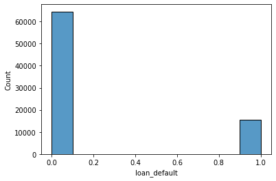

```python
# plot target var by sns
sns.histplot(df.loan_default, binwidth=0.1)
```

```python
# print df columns
df.columns
```

```
Index(['Unnamed: 0', 'Unnamed: 0.1', 'id', 'loan_default', 'AP001', 'AP002',
       'AP003', 'AP004', 'AP005', 'AP006', 'AP007', 'AP008', 'AP009', 'TD001',
       'TD002', 'TD005', 'TD006', 'TD009', 'TD010', 'TD013', 'TD014', 'TD015',
       'TD022', 'TD023', 'TD024', 'TD025', 'TD026', 'TD027', 'TD028', 'TD029',
       'TD044', 'TD048', 'TD051', 'TD054', 'TD055', 'TD061', 'TD062', 'CR004',
       'CR005', 'CR009', 'CR012', 'CR015', 'CR017', 'CR018', 'CR019', 'PA022',
       'PA023', 'PA028', 'PA029', 'PA030', 'PA031', 'CD008', 'CD018', 'CD071',
       'CD072', 'CD088', 'CD100', 'CD101', 'CD106', 'CD107', 'CD108', 'CD113',
       'CD114', 'CD115', 'CD117', 'CD118', 'CD120', 'CD121', 'CD123', 'CD130',
       'CD131', 'CD132', 'CD133', 'CD135', 'CD136', 'CD137', 'CD152', 'CD153',
       'CD160', 'CD162', 'CD164', 'CD166', 'CD167', 'CD169', 'CD170', 'CD172',
       'CD173', 'MB005', 'MB007'],
      dtype='object')
```

```python
# list all required variables
features = ['AP001', 'AP003', 'AP008',
            'CR009', 'CR015', 'CR019',
            'PA022', 'PA023', 'PA029',
            'TD001', 'TD005', 'TD006', 'TD009', 'TD010', 'TD014']
```

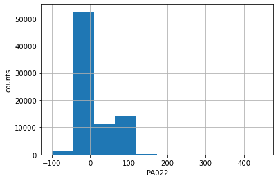

```python
# plot univariate var PA022
df.PA022.hist()
plt.xlabel('PA022')
plt.ylabel('counts')
```

```python
# write a function and loop through
def binning(var):
    df[var + '_bin'] = pd.qcut(df[var],10,duplicates='drop').values.add_categories("NoData")
    df[var + '_bin'] = df[var + '_bin'].fillna("NoData").astype(str)
    df[var + '_bin'].value_counts(dropna=False)

#to_bin = ['fixed acidity', 'pH', 'volatile acidity', 'sulphates', 'citric acid', 'residual sugar', 'chlorides']
for i in features:
    binning(i)

features_bin = [f + '_bin' for f in features]
features_bin
```

```
['AP001_bin',
 'AP003_bin',
 'AP008_bin',
 'CR009_bin',
 'CR015_bin',
 'CR019_bin',
 'PA022_bin',
 'PA023_bin',
 'PA029_bin',
 'TD001_bin',
 'TD005_bin',
 'TD006_bin',
 'TD009_bin',
 'TD010_bin',
 'TD014_bin']
```

```python
z = df.groupby('PA022_bin')['loan_default'].agg(['count','mean']).reset_index() # What does ".reset_index()" do?
z['count_pcnt'] = z['count']/z['count'].sum()
z
```

|  | PA022_bin | count | mean | count_pcnt |
| --- | --- | --- | --- | --- |
| 0 | (-1.0, 20.0] | 3672 | 0.225218 | 0.045900 |
| 1 | (-99.001, -1.0] | 52173 | 0.170433 | 0.652162 |
| 2 | (20.0, 59.0] | 8065 | 0.231494 | 0.100812 |
| 3 | (59.0, 87.0] | 7909 | 0.239095 | 0.098863 |
| 4 | (87.0, 448.0] | 7800 | 0.245641 | 0.097500 |
| 5 | NoData | 381 | 0.249344 | 0.004763 |

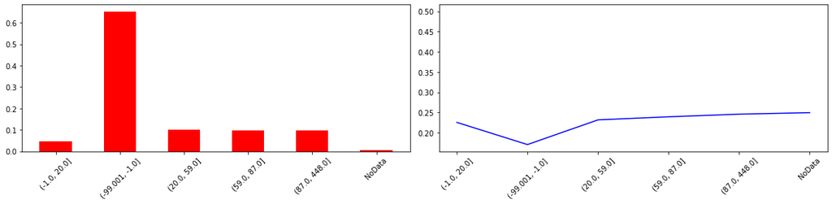

```python
# Plot the graphs
import matplotlib
import matplotlib.pyplot as plt
import numpy as np

z= df.groupby('PA022_bin')['loan_default'].agg(['count','mean']).reset_index()
z['count_pcnt'] = z['count']/z['count'].sum()
x = z['PA022_bin']
y_mean = z['mean']
count_pcnt = z['count_pcnt']
ind = np.arange(0, len(x))
width = .5

# The X count
fig = plt.figure(figsize=(16,4))
plt.subplot(121)
plt.bar(ind, count_pcnt, width, color='r')
plt.xticks(ind,x.tolist(), rotation=45)

# The Y
plt.subplot(122)
# plt.bar(ind, y_mean, width, color='b')
plt.plot(ind, y_mean , width, color='b')
plt.xticks(ind,x.tolist(), rotation=45)
plt.tight_layout()
plt.show()
```

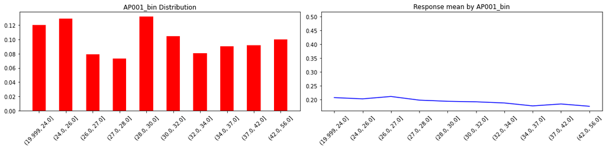

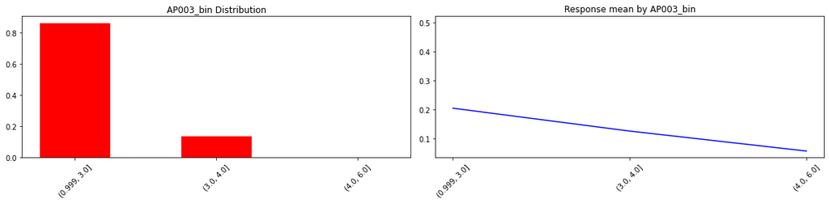

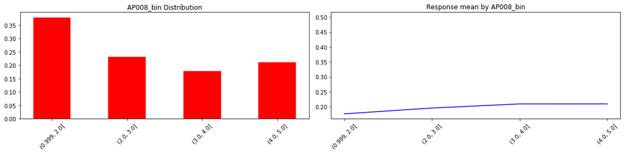

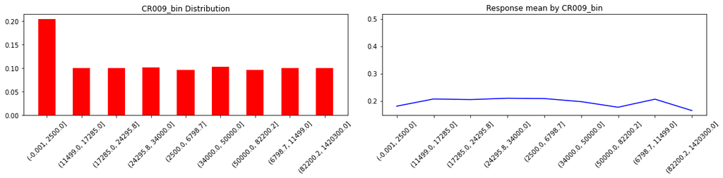

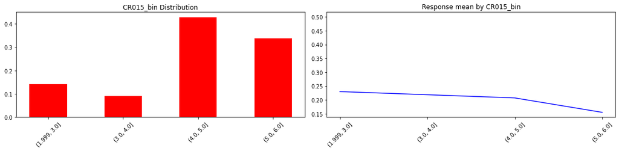

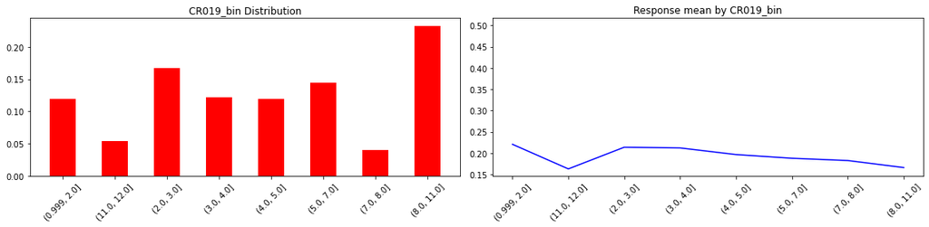

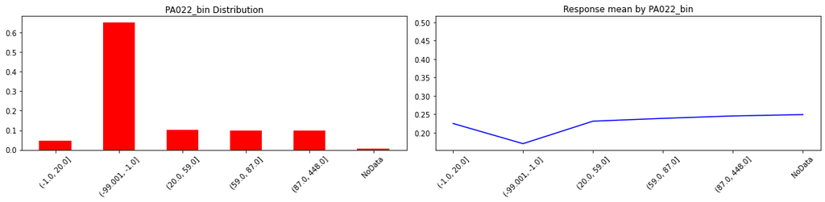

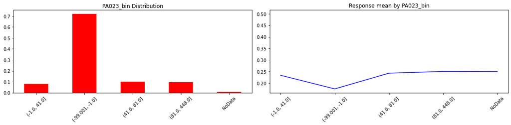

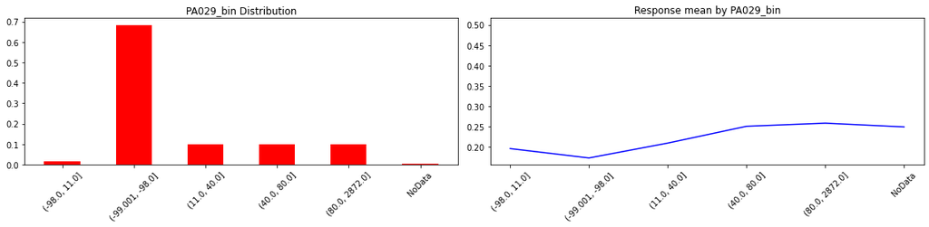

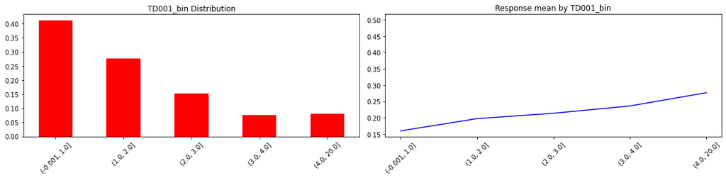

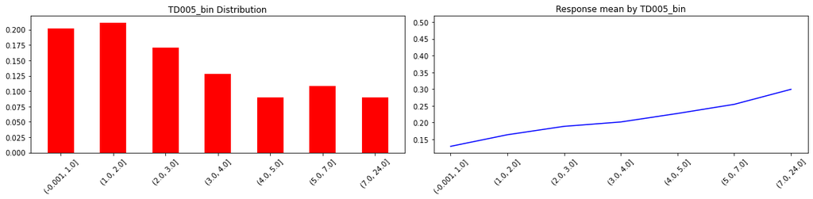

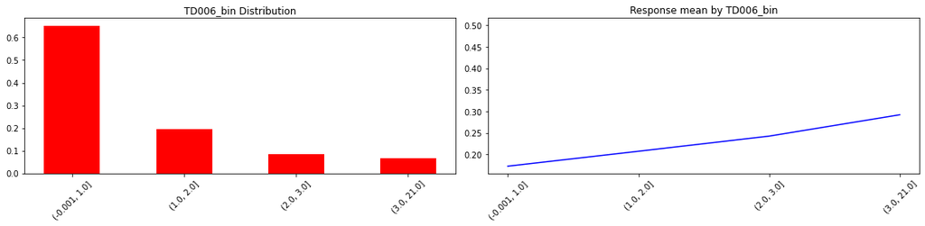

[3 more figures not shown]

```python
# define a func and utitlize a for loop to plot the distribution of y by X

def plot_X_and_Y(var):

    z= df.groupby(var)['loan_default'].agg(['count','mean']).reset_index()
    z['count_pcnt'] = z['count']/z['count'].sum()
    x = z[var]
    y_mean = z['mean']
    count_pcnt = z['count_pcnt']
    ind = np.arange(0, len(x))
    width = .5

    fig = plt.figure(figsize=(16,4))
    plt.subplot(121)
    plt.bar(ind, count_pcnt, width, color='r')
    #plt.ylabel('X')
    plt.title(var + ' Distribution')
    plt.xticks(ind,x.tolist(), rotation=45)

    plt.subplot(122)
    #plt.bar(ind, y_mean, width, color='b')
    plt.plot(ind, y_mean, width, color='b')
    #plt.ylabel('Y by X')
    plt.xticks(ind,x.tolist(), rotation=45)
    plt.tight_layout()
    plt.title('Response mean by ' + var)
    plt.show()

for i in features_bin:
    plot_X_and_Y(i)
```

### Above EDA and plots are able to show the relationship between X (features) and Y (loan default).

Back to Table of Content

[1. Loan Default by YR_AGE] The distribution of loan default by age likes a "W" symbol with lower tail on the right side. Year of age in lower, mdium, and higher parts are the major sections to make loan default, Especially in 19.9-26 and 28-30 age. It is reasonable since youths more likely to break contracts due to insufficient budgets. The response mean by age shows similar trend with higher in the lowest age range.

[4. Loan Default by AMT_LOAN_TOTAL] The distribution of loan default by amount loan total is mostly in the range 0-2500. In this category, people is the most to make laon default since they might have less loan in total which has higher proportion to pay the debt. The response mean is flatted except two highest amount loan total with low mean of loan default.

[5. Loan Default by MONTH_CREDIT_CARD_MOB_MAX] The distribution of loan default by month credit card mox max concentrates on the higher sections, 4-6. Although lower month credit card mox max is the minor parts, they actually have high possibilities to violate treaties.

[6. Loan Default by SCORE_SINGLE_DEBIT_CARD_LIMIT] The distribution of loan default by score single debit card limit likes a "W" symbol with higher tail on the right side, especially 8-11. On the other hand, as people has higher score single debit card limit, they arae less likely to act loan default.

[7. Loan Default by DAYS_BTW_APPLICATION_AND_FIRST_COLLECTION_OR_HIGH_RISK_CALL] There are numerous NA and anomalies (negative numbers) in the distribution of loan default by days between application and first collection or high risk call. Therefore, we need to take off these in later steps. Other than othat, higher application and first collection or high risk call signifies higher proportion in loan default.

[8. Loan Default by DAYS_BTW_APPLICATION_AND_FIRST_COLLECTION_CALL] There are numerous NA and anomalies (negative numbers) in the distribution of loan default by days between application and first collection call. Therefore, we need to take off these in later steps. Other than othat, higher application and first collection call reveals higher ratio loan default.

[9. Loan Default by AVG_LEN_COLLECTION_OR_HIGH_RISK_INBOUND_CALLS] There are numerous NA and anomalies (negative numbers) in the distribution of loan default by average length collection or high risk inbound. Therefore, we need to take off these in later steps. Other than othat, higher average length collection call displays higher rate in loan default.

[10. Loan Default by TD_CNT_QUERY_LAST_7Day_P2P] The distribution of loan default by td cnt query last 7 day P2P is basically inverse of the response mean. Most people are in lowest part and decreases progressively in distribution. On the contrary, the least people are in lowest section and increase progressively in response mean.

[11. Loan Default by TD_CNT_QUERY_LAST_1MON_P2P] The distribution of loan default by td cnt query last 1 month P2P. Most people are in lower parts, decreases progressively, and rebouns in the higher sections in distribution. In contrast, the least people are in lowest section and increase progressively in response mean.

[12. Loan Default by TD_CNT_QUERY_LAST_1MON_SMALL_LOAN] The distribution of loan default by td cnt query last 1 month samll loan is basically inverse of the response mean. Most people are in lowest part and decreases progressively in distribution. Conversely, the least people are in lowest section and increase progressively in response mean.

[13. Loan Default by TD_CNT_QUERY_LAST_3MON_P2P] The distribution of loan default by td cnt query last 3 month P2P is irregular with most people in 7-8. On the ohter hand, the response mean by td cnt query last 3 month P2P consistently increases.

[14. Loan Default by TD_CNT_QUERY_LAST_3MON_SMALL_LOAN] The distribution of loan default by td cnt query last 3 month small loan is basically inverse of the response mean. Most people are in lowest part and decrease progressively in distribution. Instead, the least people are in lowest section and increase progressively in response mean.

[15. Loan Default by TD_CNT_QUERY_LAST_6MON_SMALL_LOAN] The distribution of loan default by td cnt query last 6 month small loan is basically inverse of the response mean. Most people are in lowest part and decrease progressively in distribution. Rather than distribution, the least people are in lowest section and increase progressively in response mean.

### [2.Feature Engineering] Perform the weight-of-evidence (WOE) transformation for the above variables according to "[A Data Scientist’s Toolkit to Encode Categorical Variables to Numeric(https://towardsdatascience.com/a-data-scientists-toolkit-to-encode-categorical-variables-to-numeric-d17ad9fae03f)"

Back to Table of Content

```python
import warnings
warnings.simplefilter(action='ignore')
def WOE(var):
    df[var] = df[var].fillna('NoData')
    k = df[[var,'loan_default']].groupby(var)['loan_default'].agg(['count','sum']).reset_index()
    k.columns = [var,'Count','Good']
    k['Bad'] = k['Count'] - k['Good']
    k['Good %'] = (k['Good'] / k['Good'].sum()*100).round(2)
    k['Bad %'] = (k['Bad'] / k['Bad'].sum()*100).round(2)
    k[var+'_WOE'] = np.log(k['Good %'] / k['Bad %']).round(2)
    k = k.sort_values(by=var+'_WOE')
    return(k)
for k in features:
    w = WOE(k)
    print(w.head())
```

```
    AP001  Count  Good  Bad  Good %  Bad %  AP001_WOE
33     53    274    37  237    0.24   0.37      -0.43
34     54    276    43  233    0.28   0.36      -0.25
25     45    981   162  819    1.05   1.27      -0.19
29     49    614   102  512    0.66   0.79      -0.18
28     48    683   116  567    0.75   0.88      -0.16
   AP003  Count  Good    Bad  Good %  Bad %  AP003_WOE
4      6     14     0     14    0.00   0.02       -inf
3      5    232    14    218    0.09   0.34      -1.33
2      4  10846  1365   9481    8.81  14.70      -0.51
1      3  23829  4145  19684   26.76  30.51      -0.13
0      1  45079  9964  35115   64.33  54.43       0.17
   AP008  Count  Good    Bad  Good %  Bad %  AP008_WOE
0      1   8438  1420   7018    9.17  10.88      -0.17
1      2  21882  3921  17961   25.32  27.84      -0.09
```

[output cut: 75 more lines]

```python
# reread and sub df
# path = 'C:/Users/Administrator/Desktop/CU/CU_SM2022/APANPS5420_001_2022_2-ANOMALYDETECTION/3'
df = pd.read_csv('./XYZloan_default_selected_vars.csv')
df_sub = pd.concat([df[features], df[['loan_default']]], axis=1)
df_sub.tail()
```

|  | AP001 | AP003 | AP008 | CR009 | CR015 | CR019 | PA022 | PA023 | PA029 | TD001 | TD005 | TD006 | TD009 | TD010 | TD014 | loan_default |
| --- | --- | --- | --- | --- | --- | --- | --- | --- | --- | --- | --- | --- | --- | --- | --- | --- |
| 79995 | 39 | 1 | 3 | 16716 | 5 | 6 | -1.0 | -1.0 | -98.0 | 2 | 2 | 0 | 4 | 0 | 3 | 0 |
| 79996 | 31 | 4 | 4 | 3388 | 5 | 5 | -1.0 | -1.0 | -98.0 | 0 | 2 | 0 | 2 | 0 | 0 | 0 |
| 79997 | 37 | 1 | 3 | 0 | 3 | 6 | -1.0 | -1.0 | -98.0 | 1 | 1 | 2 | 1 | 2 | 2 | 0 |
| 79998 | 38 | 1 | 2 | 20200 | 4 | 5 | -1.0 | -1.0 | -98.0 | 0 | 0 | 0 | 0 | 0 | 0 | 0 |
| 79999 | 25 | 3 | 3 | 15600 | 5 | 5 | 38.0 | 38.0 | 17.4 | 5 | 8 | 4 | 8 | 6 | 6 | 1 |

```python
# check null val & pct in features
def null_cell(df_sub):
    dfx = df_sub[features].copy()
    missing_values = dfx.isnull().sum()
    missing_values_per = dfx.isnull().sum() / dfx.isnull().count()
    null_values = pd.concat([missing_values, missing_values_per],axis=1, keys = ['the_null','the_null_perc'])
    null_values = null_values.sort_values('the_null',ascending=False)
    return null_values[null_values['the_null']>0]

fill_list = (null_cell(df_sub))#.index
fill_list
```

|  | the_null | the_null_perc |
| --- | --- | --- |
| PA022 | 381 | 0.004763 |
| PA023 | 381 | 0.004763 |
| PA029 | 381 | 0.004763 |

```python
df_mean = df_sub # Do you know this is different from "df_mean = df.copy()?"" This just point to the same data frame. It does not create a copy.
df_mean = df_sub.copy() # Here create a physical copy of df.
```

```python
# take off na with mean
for col in fill_list.index:
    df_mean.loc[:,col].fillna(df_mean.loc[:,col].mean(),inplace=True)
fill_list_mean = (null_cell(df_mean[features]))#.index
fill_list_mean
```

|  | the_null | the_null_perc |
| --- | --- | --- |

```python
# check df_mean
df_mean.describe()
```

|  | AP001 | AP003 | AP008 | CR009 | CR015 | CR019 | PA022 | PA023 | PA029 | TD001 | TD005 | TD006 | TD009 | TD010 | TD014 | loan_default |
| --- | --- | --- | --- | --- | --- | --- | --- | --- | --- | --- | --- | --- | --- | --- | --- | --- |
| count | 80000.000000 | 80000.000000 | 80000.000000 | 8.000000e+04 | 80000.000000 | 80000.000000 | 80000.000000 | 80000.000000 | 80000.000000 | 80000.000000 | 80000.000000 | 80000.000000 | 80000.00000 | 80000.000000 | 80000.000000 | 80000.000000 |
| mean | 31.706913 | 2.014925 | 3.117200 | 3.518711e+04 | 4.924750 | 6.199038 | 19.298811 | 14.828822 | -42.407356 | 1.986962 | 3.593037 | 1.345700 | 5.40600 | 2.020812 | 2.603662 | 0.193600 |
| std | 7.075070 | 1.196806 | 1.306335 | 6.359684e+04 | 1.094305 | 3.359354 | 39.610816 | 36.921139 | 96.774893 | 1.807445 | 2.799570 | 1.413362 | 4.02311 | 1.973988 | 2.505840 | 0.395121 |
| min | 20.000000 | 1.000000 | 1.000000 | 0.000000e+00 | 2.000000 | 1.000000 | -99.000000 | -99.000000 | -99.000000 | 0.000000 | 0.000000 | 0.000000 | 0.00000 | 0.000000 | 0.000000 | 0.000000 |
| 25% | 27.000000 | 1.000000 | 2.000000 | 4.700000e+03 | 5.000000 | 3.000000 | -1.000000 | -1.000000 | -98.000000 | 1.000000 | 2.000000 | 0.000000 | 3.00000 | 1.000000 | 1.000000 | 0.000000 |
| 50% | 30.000000 | 1.000000 | 3.000000 | 1.728500e+04 | 5.000000 | 5.000000 | -1.000000 | -1.000000 | -98.000000 | 2.000000 | 3.000000 | 1.000000 | 4.00000 | 2.000000 | 2.000000 | 0.000000 |
| 75% | 35.000000 | 3.000000 | 4.000000 | 4.075000e+04 | 6.000000 | 10.000000 | 40.000000 | 14.828822 | 25.500000 | 3.000000 | 5.000000 | 2.000000 | 7.00000 | 3.000000 | 4.000000 | 0.000000 |
| max | 56.000000 | 6.000000 | 5.000000 | 1.420300e+06 | 6.000000 | 12.000000 | 448.000000 | 448.000000 | 2872.000000 | 20.000000 | 24.000000 | 21.000000 | 46.00000 | 35.000000 | 43.000000 | 1.000000 |

### [3. Build a simple decision tree model or a logistic regression model with the above variables.]

Back to Table of Content

```
- You already learned how to build a decision tree or a logistic regression in the prerequisite course. In this homework you can build the model in either R or Python.
- The target variable is "loan_default".  Remember to do data split for train and test first. The test dataset should not be used in any EDA.
- Describe why your feature transformation enhanced your model. Use a metric such as the standard ROC to show your model improvement. You do not need to perform the gains table or lift.
```

```python
# split train & test data
X = df_mean[features]
y = df_mean.loan_default
X_train, X_test, y_train, y_test = train_test_split(X, y, train_size=0.75, random_state=0)
```

```python
# First, specify the model
dtree = DTC(min_samples_leaf=5, max_depth=6)
dtree.fit(X_train, y_train)
```

```
DecisionTreeClassifier(max_depth=6, min_samples_leaf=5)
```

```python
# Show the Importance of the "key questions" with the "variable importance"
importances = pd.DataFrame({'feature': X_train.columns, 'importance': np.round(dtree.feature_importances_,5)})
importances = importances.sort_values('importance',ascending=False)
importances
```

|  | feature | importance |
| --- | --- | --- |
| 12 | TD009 | 0.38384 |
| 1 | AP003 | 0.21998 |
| 4 | CR015 | 0.09844 |
| 10 | TD005 | 0.05657 |
| 8 | PA029 | 0.05537 |
| 6 | PA022 | 0.04574 |
| 14 | TD014 | 0.02778 |
| 7 | PA023 | 0.02597 |
| 9 | TD001 | 0.02520 |
| 13 | TD010 | 0.01603 |
| 0 | AP001 | 0.01172 |
| 3 | CR009 | 0.01149 |
| 11 | TD006 | 0.01014 |
| 2 | AP008 | 0.00943 |
| 5 | CR019 | 0.00229 |

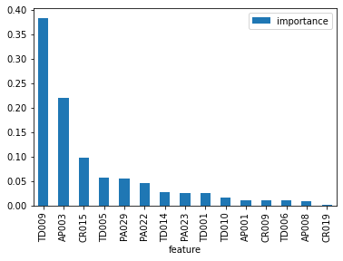

```python
importances.plot.bar(x='feature')
```

```python
# Predict new observations
predictions = dtree.predict(X_test[0:10])
predictions
```

```
array([0, 0, 0, 0, 0, 0, 0, 0, 0, 0], dtype=int64)
```

```python
dtree.predict_proba(X_test[0:10])
```

```
array([[0.85008237, 0.14991763],
       [0.78895899, 0.21104101],
       [0.84810974, 0.15189026],
       [0.88971763, 0.11028237],
       [0.73535273, 0.26464727],
       [0.88107639, 0.11892361],
       [0.88107639, 0.11892361],
       [0.55514706, 0.44485294],
       [0.84937817, 0.15062183],
       [0.63362069, 0.36637931]])
```

```python
y_pred = dtree.predict_proba(X_test[0:10])[:,1]
y_pred
```

```
array([0.14991763, 0.21104101, 0.15189026, 0.11028237, 0.26464727,
       0.11892361, 0.11892361, 0.44485294, 0.15062183, 0.36637931])
```

```python
# Confusion Matrix
predictions = dtree.predict(X_test[features])
print(accuracy_score(y_test,predictions))
```

```
0.81075
```

```python
np.count_nonzero(y_test == 1)
```

```
3775
```

```python
confusion_matrix(y_test,predictions)
```

```
array([[16174,    51],
       [ 3734,    41]], dtype=int64)
```

```python
cm = pd.DataFrame(confusion_matrix(y_test,predictions))
cm.rename(columns={0:'Predicted NOT Default', 1:'Predicted Default'},
         index = {0:'Actual NOT Default',1:'Actual Default'},inplace=True)
cm
```

|  | Predicted NOT Default | Predicted Default |
| --- | --- | --- |
| Actual NOT Default | 16174 | 51 |
| Actual Default | 3734 | 41 |

```python
# ROC
import matplotlib.pyplot as plt
from sklearn.metrics import roc_curve,roc_auc_score

y_pred = dtree.predict_proba(X_test[features])[:,1]
roc_auc_value = roc_auc_score(y_test,y_pred)
roc_auc_value
```

```
0.6349713446055572
```

```python
fpr, tpr, thresholds = roc_curve(y_test, y_pred)
[fpr, tpr, thresholds]
```

```
[array([0.00000000e+00, 1.23266564e-04, 1.84899846e-04, 3.08166410e-04,
        2.58859784e-03, 3.14329738e-03, 3.57473035e-03, 5.36209553e-03,
        1.18952234e-02, 1.63944530e-02, 1.77503852e-02, 1.78120185e-02,
        2.26194145e-02, 2.37288136e-02, 2.74884438e-02, 3.46995378e-02,
        5.25731895e-02, 5.78736518e-02, 8.35130971e-02, 9.22650231e-02,
        9.42372881e-02, 1.03975347e-01, 1.22033898e-01, 1.40770416e-01,
        1.45084746e-01, 1.53158706e-01, 1.58952234e-01, 1.96055470e-01,
        2.08443760e-01, 2.08813559e-01, 2.33158706e-01, 2.45485362e-01,
        2.48690293e-01, 2.58181818e-01, 2.65392912e-01, 2.78582435e-01,
        3.25053929e-01, 3.76887519e-01, 4.01171032e-01, 4.11402157e-01,
        4.60092450e-01, 4.63235747e-01, 4.68166410e-01, 4.88258860e-01,
        4.89429892e-01, 4.94175655e-01, 4.94298921e-01, 6.00554700e-01,
        6.24406780e-01, 6.61510015e-01, 6.72295840e-01, 6.72480740e-01,
        6.89306626e-01, 7.51309707e-01, 7.57473035e-01, 7.60554700e-01,
        8.01602465e-01, 8.34822804e-01, 8.60462250e-01, 8.87889060e-01,
        9.73066256e-01, 9.94884438e-01, 1.00000000e+00]),
 array([0.00000000e+00, 2.64900662e-04, 2.64900662e-04, 5.29801325e-04,
        1.03311258e-02, 1.08609272e-02, 1.24503311e-02, 1.77483444e-02,
        3.60264901e-02, 4.58278146e-02, 4.87417219e-02, 4.90066225e-02,
        5.72185430e-02, 5.90728477e-02, 6.56953642e-02, 8.15894040e-02,
        1.25562914e-01, 1.39337748e-01, 1.84105960e-01, 1.98675497e-01,
        2.00529801e-01, 2.19337748e-01, 2.45033113e-01, 2.70993377e-01,
        2.78410596e-01, 2.87947020e-01, 2.99602649e-01, 3.57615894e-01,
        3.76953642e-01, 3.76953642e-01, 4.03973510e-01, 4.17483444e-01,
        4.20132450e-01, 4.28344371e-01, 4.41854305e-01, 4.59602649e-01,
        5.10993377e-01, 5.71125828e-01, 5.99470199e-01, 6.08741722e-01,
        6.58543046e-01, 6.64370861e-01, 6.67814570e-01, 6.85827815e-01,
        6.86357616e-01, 6.89801325e-01, 6.90066225e-01, 7.76688742e-01,
        7.90463576e-01, 8.17483444e-01, 8.24900662e-01, 8.25165563e-01,
        8.36026490e-01, 8.77615894e-01, 8.79470199e-01, 8.82119205e-01,
        9.09139073e-01, 9.28476821e-01, 9.44105960e-01, 9.57350993e-01,
        9.85430464e-01, 9.97350993e-01, 1.00000000e+00]),
 array([2.        , 1.        , 0.875     , 0.71428571, 0.54032258,
        0.52173913, 0.5       , 0.46896552, 0.44485294, 0.44059406,
        0.40495868, 0.4       , 0.39403974, 0.38461538, 0.36637931,
        0.35021097, 0.33776792, 0.33240997, 0.3322314 , 0.30703259,
        0.30252101, 0.28571429, 0.28548256, 0.2853598 , 0.27887324,
        0.2769556 , 0.27375566, 0.26464727, 0.24617347, 0.23809524,
        0.23169955, 0.23034483, 0.22435897, 0.22406639, 0.22098214,
        0.21782178, 0.21171335, 0.21104101, 0.20776699, 0.20344828,
        0.20012995, 0.18316832, 0.18211921, 0.17926186, 0.15909091,
        0.15734266, 0.15384615, 0.15189026, 0.15130568, 0.15062183,
        0.14991763, 0.14285714, 0.13764338, 0.13631124, 0.12654321,
        0.1257485 , 0.11892361, 0.11028237, 0.10925539, 0.09427121,
        0.07905315, 0.06999125, 0.06521739])]
```

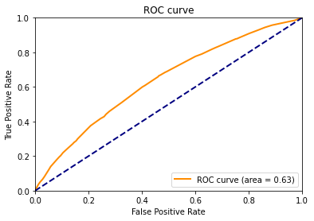

```python
import matplotlib.pyplot as plt
lw=2
plt.figure(figsize=(6,4))
plt.plot(fpr,tpr, color='darkorange',lw=lw,label='ROC curve (area = %0.2f)' %roc_auc_value)
plt.plot([0,1],[0,1], color='navy',lw=lw,linestyle='--')
plt.xlim([0,1])
plt.ylim([0,1])
plt.xlabel('False Positive Rate')
plt.ylabel('True Positive Rate')
plt.title('ROC curve')
plt.legend(loc='lower right')
plt.show()
```

- ROC curve is a performance measurement for the classification problems at various threshold settings. As we can see from ROC and confusion matrix, true positive rate and false positice rate are tradeoff. The decision tree model is better than the diagnoal base line.

### [4. Handling imbalanced dataset in machine learning]

Back to Table of Content

#### What is imblanced dataset and how to solve it?

- The issue of class imbalance can result in a serious bias towards the majority class, reducing the classification performance and increasing the number of false negatives. How can we alleviate the issue? The most commonly used techniques are data resampling either under-sampling the majority of the class, or oversampling the minority class, or a mix of both. This will result in improved classification performance.

#### Order matters

- We should perform under / over sample (including SMOTE) only on training data, and measure f1 on original data distribution (test data). Moreover, if you divide oversample data with train_test_split then you have no control over the distribution of duplicated items for test and train. Which means that you can have the same observation in both test and train, which means you test partially on the training set - that's why the results increase. So first divide into train / test, and then perform operations only on the training set, and the test set should be without any changes.

```python
import matplotlib.pyplot as plt
print(f'total dataset: \n{df_mean.loan_default.value_counts()} \n'
      f'train dataset:\n{y_train[:].value_counts()} \n'
      f'test dataset:\n{y_test[:].value_counts()}')
print(f'no_loan vs loan in total dataset: {round(df_mean.loan_default.value_counts()[0]/df_mean.loan_default.value_counts()[1], 2)}\n'
      f'no_loan vs loan in train dataset: {round(y_train[:].value_counts()[0]/y_train[:].value_counts()[1], 2)}\n'
      f'no_loan vs loan in test dataset: {round(y_test[:].value_counts()[0]/y_test[:].value_counts()[1], 2)}\n')
```

```
total dataset:
0    64512
1    15488
Name: loan_default, dtype: int64
train dataset:
0    48287
1    11713
Name: loan_default, dtype: int64
test dataset:
0    16225
1     3775
Name: loan_default, dtype: int64
no_loan vs loan in total dataset: 4.17
no_loan vs loan in train dataset: 4.12
no_loan vs loan in test dataset: 4.3
```

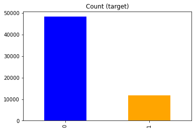

```python
y_train[:].value_counts().plot(kind='bar', title='Count (target)', color=['blue', 'orange'])
```

- My thoughts: no loan default verse loan default is around 4.17, 4.12, and 4.3 in total dataset, train dataset, and test dataset, which is obviously a imbalanced dataset

```python
from sklearn.preprocessing import StandardScaler
scaler = StandardScaler()
X_train_scaled = scaler.fit_transform(X_train)
X_test_scaled = scaler.transform(X_test)
```

```python
# sample data for plot
X_dd = pd.DataFrame(X_train_scaled).sample(frac=0.02, replace=False, random_state=23)
y_dd = y_train.sample(frac=0.02, replace=False, random_state=23)
X_dd = np.array(X_dd)
y_dd = np.array(y_dd)
X_tt = pd.DataFrame(X_test_scaled).sample(frac=0.02, replace=False, random_state=23)
y_tt = y_test.sample(frac=0.02, replace=False, random_state=23)
```

```python
from sklearn.decomposition import PCA
import pylab as pl

pca = PCA(n_components=2).fit(X_dd)
pca_2d = pca.transform(X_dd)
pd.DataFrame(pca_2d).describe()
```

|  | 0 | 1 |
| --- | --- | --- |
| count | 1.200000e+03 | 1.200000e+03 |
| mean | -7.401487e-18 | -9.843977e-17 |
| std | 2.000285e+00 | 1.576815e+00 |
| min | -3.490911e+00 | -5.150075e+00 |
| 25% | -1.400245e+00 | -9.763355e-01 |
| 50% | -3.178719e-01 | -5.333074e-01 |
| 75% | 1.048691e+00 | 1.007495e+00 |
| max | 1.719944e+01 | 5.892385e+00 |

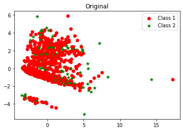

```python
from sklearn.decomposition import PCA
import pylab as pl
def plot_this(X_rs,y_rs,method):
  # Use principal component to condense the 10 features to 2 features
  pca = PCA(n_components=2).fit(X_rs)
  pca_2d = pca.transform(X_rs)
  # Assign colors
  for i in range(0, pca_2d.shape[0]):
    if y_rs[i] == 0:
      c1 = pl.scatter(pca_2d[i,0],pca_2d[i,1],c='r', marker='o')
    elif y_rs[i] == 1:
      c2 = pl.scatter(pca_2d[i,0],pca_2d[i,1],c='g', marker='*')
  pl.legend([c1, c2], ['Class 1', 'Class 2'])
  pl.title(method)
  # pl.axis([-4, 5, -4, 4])  # x axis (-4,5), y axis (-4,4)
  pl.show()

# X_train_scaled_sample = pd.DataFrame(X_train_scaled).sample(frac=.02, replace=False, random_state=23)
# y_train_scaled_sample = y_train.sample(frac=.02, replace=False, random_state=23)
# X_train_scaled_sample = np.array(X_train_scaled_sample)
# y_train_scaled_sample = np.array(y_train_scaled_sample)
plot_this(X_dd, y_dd, 'Original')
```

- For ease of visualization, I use principal component analysis to reduce the dimensions and pick the first two principal components. A scatterplot for the dataset is shown above.

### Mitigating Imbalanced Dataset

#### Method 1: Undersampling

Back to Table of Content

- Thoughts: Tomek links-This technique performs under-sampling by generating centroids based on clustering methods. The data will be previously grouped by similarity, in order to preserve information. Cluster Centroids-This technique performs under-sampling by generating centroids based on clustering methods. The data will be previously grouped by similarity, in order to preserve information. reference: https://www.kaggle.com/rafjaa/resampling-strategies-for-imbalanced-datasets

https://www.kaggle.com/code/residentmario/undersampling-and-oversampling-imbalanced-data/notebook

```python
from collections import Counter
print('Original dataset shape {}'.format(Counter(y)))
print('Training dataset shape {}'.format(Counter(y_train)))
print('Sampling dataset shape {}'.format(Counter(y_dd)))
```

```
Original dataset shape Counter({0: 64512, 1: 15488})
Training dataset shape Counter({0: 48287, 1: 11713})
Sampling dataset shape Counter({0: 976, 1: 224})
```

[output not shown]

[figure not shown]

```python
from imblearn.datasets import make_imbalance
from collections import Counter
X_rs, y_rs = make_imbalance(X_dd, y_dd, sampling_strategy={0: 200, 1: 100},
                      random_state=0)
print('Random undersampling {}'.format(Counter(y_rs)))
plot_this(X_rs,y_rs,'Random undersampling')
```

```
Random undersampling Counter({0: 200, 1: 100})
```

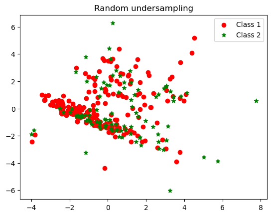

```
Cluster centriods undersampling Counter({0: 200, 1: 100})
```

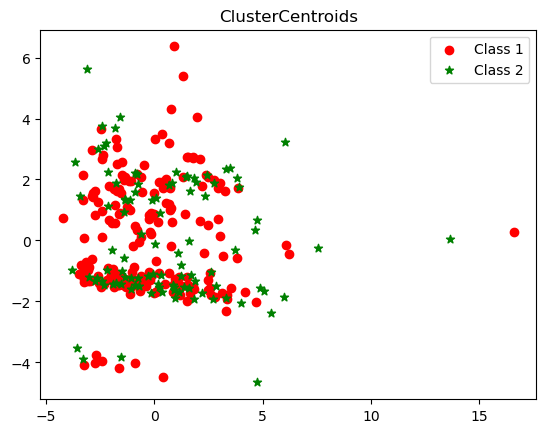

```
TomekLinks undersampling Counter({0: 901, 1: 224})
```

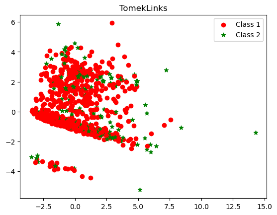

```
NearestNeighbours Clearning Rule undersampling Counter({0: 554, 1: 224})
```

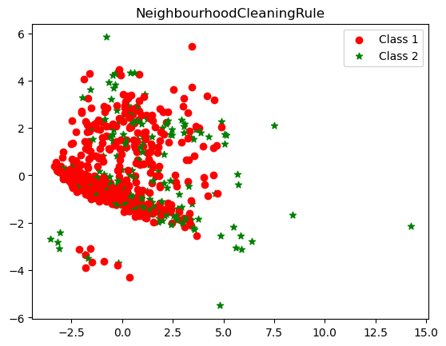

```
NearMissCounter({0: 224, 1: 224})
```

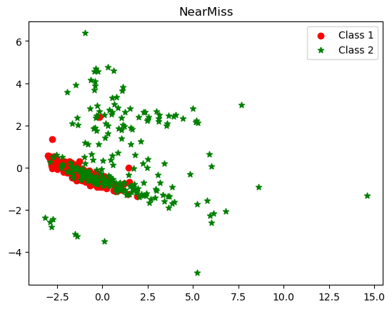

```python
from imblearn.under_sampling import (RandomUnderSampler,
                                     ClusterCentroids,
                                     TomekLinks,
                                     NeighbourhoodCleaningRule,
                                     NearMiss)
# RandomUnderSampler
sampler = RandomUnderSampler(sampling_strategy={0: 200, 1: 100})
X_rus, y_rus = sampler.fit_resample(X_dd, y_dd)
print('Random undersampling {}'.format(Counter(y_rus)))
plot_this(X_rus, y_rus, 'Random undersampling')

# ClusterCentroids
sampler = ClusterCentroids(sampling_strategy={0: 200, 1: 100})
X_ccu, y_ccu = sampler.fit_resample(X_dd, y_dd)
print('Cluster centriods undersampling {}'.format(Counter(y_ccu)))
plot_this(X_ccu, y_ccu, 'ClusterCentroids')

# TomekLinks
sampler = TomekLinks()
X_tlu, y_tlu = sampler.fit_resample(X_dd, y_dd)
print('TomekLinks undersampling {}'.format(Counter(y_tlu)))
plot_this(X_tlu, y_tlu,'TomekLinks')

# NeighbourhoodCleaningRule
sampler = NeighbourhoodCleaningRule()
X_ncu, y_ncu = sampler.fit_resample(X_dd, y_dd)
print('NearestNeighbours Clearning Rule undersampling {}'.format(Counter(y_ncu)))
plot_this(X_ncu, y_ncu,'NeighbourhoodCleaningRule')

# NearMiss
sampler = NearMiss()
X_nmu, y_nmu = sampler.fit_resample(X_dd, y_dd)
print('NearMiss{}'.format(Counter(y_nmu)))
plot_this(X_nmu, y_nmu,'NearMiss')
```

```python
# take NearMiss as an example
import h2o
h2o.init()
df = pd.concat([pd.DataFrame(X_nmu), pd.DataFrame(y_nmu)], axis=1)
df.head()
```

```
Checking whether there is an H2O instance running at http://localhost:54321 . connected.
```

[output not shown]

|  | 0 | 1 | 2 | 3 | 4 | 5 | 6 | 7 | 8 | 9 | 10 | 11 | 12 | 13 | 14 | 0 |
| --- | --- | --- | --- | --- | --- | --- | --- | --- | --- | --- | --- | --- | --- | --- | --- | --- |
| 0 | -0.097819 | -0.847725 | 1.443939 | -0.520940 | 0.070577 | 1.432556 | -0.513498 | -0.431024 | -0.570474 | -0.547853 | -0.927695 | -0.246233 | -1.100199 | -0.520575 | -0.642998 | 0 |
| 1 | -0.662918 | -0.847725 | 0.678546 | -0.552350 | 0.070577 | 1.730506 | -0.513498 | -0.431024 | -0.570474 | -0.547853 | -0.927695 | -0.246233 | -1.100199 | -0.520575 | -0.642998 | 0 |
| 2 | -0.662918 | -0.847725 | 1.443939 | -0.552350 | 0.070577 | 1.432556 | -0.513498 | -0.431024 | -0.570474 | -1.099874 | -0.927695 | -0.246233 | -0.601792 | -0.520575 | -0.642998 | 0 |
| 3 | 0.326006 | -0.847725 | 1.443939 | -0.263378 | 0.983017 | -0.355141 | -0.513498 | -0.431024 | -0.570474 | -1.099874 | -1.284608 | -0.954682 | -0.850996 | -1.029354 | -0.642998 | 0 |
| 4 | -0.804193 | -0.847725 | 1.443939 | -0.473825 | 0.983017 | -0.653090 | -0.513498 | -0.431024 | -0.570474 | -0.547853 | -0.927695 | -0.246233 | -1.100199 | -0.520575 | -0.243107 | 0 |

```python
f = features.copy()
f.append('loan_default')
df.columns = f
from sklearn.model_selection import train_test_split
train,test = train_test_split(df, test_size=0.2, random_state=23)
df_hex = h2o.H2OFrame(df)
train_hex = h2o.H2OFrame(train)
test_hex = h2o.H2OFrame(test)
```

```
Parse progress: |████████████████████████████████████████████████████████████████| (done) 100%
Parse progress: |████████████████████████████████████████████████████████████████| (done) 100%
Parse progress: |████████████████████████████████████████████████████████████████| (done) 100%
```

```python
predictors = features
target = 'loan_default'
```

```python
from h2o.estimators.random_forest import H2ORandomForestEstimator
rf_v1 = H2ORandomForestEstimator(
        model_id = 'rf_v1',
        ntrees = 100,
        nfolds=10,
        min_rows=10,
        seed=23)
rf_v1.train(predictors,target,training_frame=train_hex)
```

```
drf Model Build progress: |██████████████████████████████████████████████████████| (done) 100%
Model Details
=============
H2ORandomForestEstimator :  Distributed Random Forest
Model Key:  rf_v1


Model Summary:
```

|  |  | number_of_trees | number_of_internal_trees | model_size_in_bytes | min_depth | max_depth | mean_depth | min_leaves | max_leaves | mean_leaves |
| --- | --- | --- | --- | --- | --- | --- | --- | --- | --- | --- |
| 0 |  | 100.0 | 100.0 | 24987.0 | 6.0 | 11.0 | 8.26 | 12.0 | 19.0 | 15.19 |

```
ModelMetricsRegression: drf
** Reported on train data. **

MSE: 0.14922486663403015
RMSE: 0.38629634561309295
MAE: 0.30888303115843974
RMSLE: 0.27153321874493747
Mean Residual Deviance: 0.14922486663403015

ModelMetricsRegression: drf
** Reported on cross-validation data. **

MSE: 0.14729436463053264
RMSE: 0.3837894795725029
MAE: 0.30779184341243354
RMSLE: 0.26940155595443116
Mean Residual Deviance: 0.14729436463053264

Cross-Validation Metrics Summary:
```

|  |  | mean | sd | cv_1_valid | cv_2_valid | cv_3_valid | cv_4_valid | cv_5_valid | cv_6_valid | cv_7_valid | cv_8_valid | cv_9_valid | cv_10_valid |
| --- | --- | --- | --- | --- | --- | --- | --- | --- | --- | --- | --- | --- | --- |
| 0 | mae | 0.305390 | 0.036407 | 0.306342 | 0.374859 | 0.288627 | 0.330858 | 0.274266 | 0.246716 | 0.334971 | 0.310514 | 0.310272 | 0.276476 |
| 1 | mean_residual_deviance | 0.144562 | 0.032186 | 0.146813 | 0.211548 | 0.122628 | 0.172887 | 0.125556 | 0.094268 | 0.158834 | 0.151872 | 0.132911 | 0.128308 |
| 2 | mse | 0.144562 | 0.032186 | 0.146813 | 0.211548 | 0.122628 | 0.172887 | 0.125556 | 0.094268 | 0.158834 | 0.151872 | 0.132911 | 0.128308 |
| 3 | r2 | 0.400876 | 0.134931 | 0.310794 | 0.152451 | 0.501701 | 0.279639 | 0.490894 | 0.616944 | 0.330530 | 0.392069 | 0.448986 | 0.484753 |
| 4 | residual_deviance | 0.144562 | 0.032186 | 0.146813 | 0.211548 | 0.122628 | 0.172887 | 0.125556 | 0.094268 | 0.158834 | 0.151872 | 0.132911 | 0.128308 |
| 5 | rmse | 0.378147 | 0.041728 | 0.383162 | 0.459944 | 0.350183 | 0.415796 | 0.354338 | 0.307030 | 0.398539 | 0.389707 | 0.364569 | 0.358202 |
| 6 | rmsle | 0.266671 | 0.028467 | 0.250275 | 0.314946 | 0.252862 | 0.298604 | 0.242771 | 0.219817 | 0.284691 | 0.275710 | 0.275582 | 0.251455 |

```
Scoring History:
```

|  |  | timestamp | duration | number_of_trees | training_rmse | training_mae | training_deviance |
| --- | --- | --- | --- | --- | --- | --- | --- |
| 0 |  | 2022-07-22 23:05:26 | 0.934 sec | 0.0 | NaN | NaN | NaN |
| 1 |  | 2022-07-22 23:05:26 | 0.938 sec | 1.0 | 0.436823 | 0.303806 | 0.190815 |
| 2 |  | 2022-07-22 23:05:26 | 0.941 sec | 2.0 | 0.414348 | 0.297721 | 0.171684 |
| 3 |  | 2022-07-22 23:05:26 | 0.944 sec | 3.0 | 0.417604 | 0.307783 | 0.174393 |
| 4 |  | 2022-07-22 23:05:26 | 0.945 sec | 4.0 | 0.403232 | 0.295295 | 0.162596 |
| 5 |  | 2022-07-22 23:05:26 | 0.946 sec | 5.0 | 0.398009 | 0.296904 | 0.158411 |
| 6 |  | 2022-07-22 23:05:26 | 0.949 sec | 6.0 | 0.395438 | 0.298210 | 0.156371 |
| 7 |  | 2022-07-22 23:05:26 | 0.951 sec | 7.0 | 0.396805 | 0.302343 | 0.157454 |
| 8 |  | 2022-07-22 23:05:26 | 0.954 sec | 8.0 | 0.393293 | 0.301765 | 0.154680 |
| 9 |  | 2022-07-22 23:05:26 | 0.957 sec | 9.0 | 0.395618 | 0.306843 | 0.156514 |
| 10 |  | 2022-07-22 23:05:26 | 0.959 sec | 10.0 | 0.398416 | 0.309892 | 0.158735 |
| 11 |  | 2022-07-22 23:05:26 | 0.961 sec | 11.0 | 0.395308 | 0.308273 | 0.156268 |
| 12 |  | 2022-07-22 23:05:26 | 0.963 sec | 12.0 | 0.392994 | 0.307462 | 0.154444 |
| 13 |  | 2022-07-22 23:05:26 | 0.966 sec | 13.0 | 0.393152 | 0.309058 | 0.154569 |
| 14 |  | 2022-07-22 23:05:26 | 0.970 sec | 14.0 | 0.391837 | 0.309801 | 0.153537 |
| 15 |  | 2022-07-22 23:05:26 | 0.972 sec | 15.0 | 0.392723 | 0.310648 | 0.154231 |
| 16 |  | 2022-07-22 23:05:26 | 0.975 sec | 16.0 | 0.392440 | 0.310841 | 0.154009 |
| 17 |  | 2022-07-22 23:05:26 | 0.976 sec | 17.0 | 0.392271 | 0.310087 | 0.153876 |
| 18 |  | 2022-07-22 23:05:26 | 0.979 sec | 18.0 | 0.392698 | 0.310716 | 0.154212 |
| 19 |  | 2022-07-22 23:05:26 | 0.982 sec | 19.0 | 0.392437 | 0.311763 | 0.154007 |

```
See the whole table with table.as_data_frame()

Variable Importances:
```

|  | variable | relative_importance | scaled_importance | percentage |
| --- | --- | --- | --- | --- |
| 0 | PA022 | 931.618958 | 1.000000 | 0.267571 |
| 1 | PA029 | 542.568665 | 0.582393 | 0.155831 |
| 2 | TD009 | 439.109375 | 0.471340 | 0.126117 |
| 3 | TD005 | 303.455475 | 0.325729 | 0.087156 |
| 4 | PA023 | 257.637695 | 0.276548 | 0.073996 |
| 5 | TD014 | 239.151291 | 0.256705 | 0.068687 |
| 6 | TD010 | 226.517349 | 0.243144 | 0.065058 |
| 7 | TD006 | 110.560890 | 0.118676 | 0.031754 |
| 8 | AP001 | 108.283592 | 0.116232 | 0.031100 |
| 9 | CR009 | 106.526985 | 0.114346 | 0.030596 |
| 10 | CR019 | 74.538895 | 0.080010 | 0.021408 |
| 11 | TD001 | 59.364090 | 0.063721 | 0.017050 |
| 12 | CR015 | 49.212719 | 0.052825 | 0.014134 |
| 13 | AP008 | 25.421303 | 0.027287 | 0.007301 |
| 14 | AP003 | 7.801109 | 0.008374 | 0.002241 |

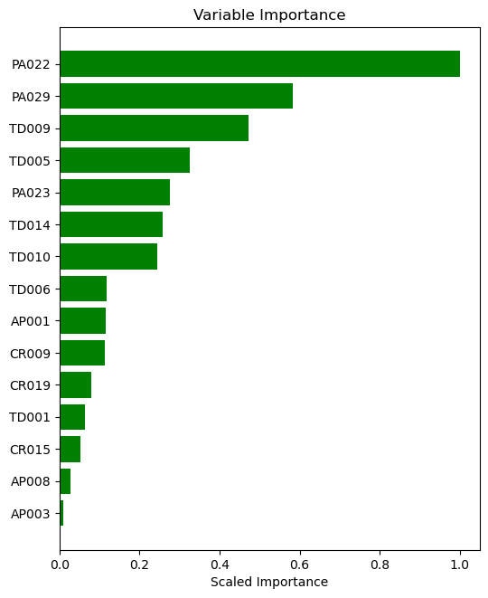

```python
def VarImp(model_name):

    from sklearn.metrics import roc_curve,auc
    from sklearn.metrics import average_precision_score
    from sklearn.metrics import precision_recall_curve
    import matplotlib.pyplot as plt

    # plot the variable importance
    plt.rcdefaults()
    variables = model_name._model_json['output']['variable_importances']['variable']
    y_pos = np.arange(len(variables))
    fig, ax = plt.subplots(figsize = (6,len(variables)/2))
    scaled_importance = model_name._model_json['output']['variable_importances']['scaled_importance']
    ax.barh(y_pos,scaled_importance,align='center',color='green')
    ax.set_yticks(y_pos)
    ax.set_yticklabels(variables)
    ax.invert_yaxis()
    ax.set_xlabel('Scaled Importance')
    ax.set_title('Variable Importance')
    plt.show()

VarImp(rf_v1)
```

```python
predictions = rf_v1.predict(test_hex)
predictions.head()
test_scores = test_hex['loan_default'].cbind(predictions).as_data_frame()
test_scores.rename(columns = {'loan_default':'actual'}, inplace=True)
test_scores.head()
```

```
drf prediction progress: |███████████████████████████████████████████████████████| (done) 100%
```

|  | actual | predict |
| --- | --- | --- |
| 0 | 1 | 0.262401 |
| 1 | 0 | 0.234391 |
| 2 | 1 | 0.956040 |
| 3 | 0 | 0.160961 |
| 4 | 1 | 0.637233 |

```python
# ROC
from sklearn.metrics import roc_curve,roc_auc_score, auc
from sklearn.metrics import average_precision_score, precision_recall_curve

dd = test_scores
RF_roc_auc_value = roc_auc_score(dd['actual'],dd['predict'])
RF_roc_auc_value
```

```
0.8049382716049382
```

```python
def createGains(model):
    predictions = model.predict(test_hex)
    test_scores = test_hex['loan_default'].cbind(predictions).as_data_frame()

    #sort on prediction (descending), add id, and decile for groups containing 1/10 of datapoints
    test_scores = test_scores.sort_values(by='predict',ascending=False)
    test_scores['row_id'] = range(0,0+len(test_scores))
    test_scores['decile'] = ( test_scores['row_id'] / (len(test_scores)/10) ).astype(int)
    #see count by decile
    test_scores.loc[test_scores['decile'] == 10]=9
    test_scores['decile'].value_counts()

    #create gains table
    gains = test_scores.groupby('decile')['loan_default'].agg(['count','sum'])
    gains.columns = ['count','actual']
    gains

    #add features to gains table
    gains['non_actual'] = gains['count'] - gains['actual']
    gains['cum_count'] = gains['count'].cumsum()
    gains['cum_actual'] = gains['actual'].cumsum()
    gains['cum_non_actual'] = gains['non_actual'].cumsum()
    gains['percent_cum_actual'] = (gains['cum_actual'] / np.max(gains['cum_actual'])).round(2)
    gains['percent_cum_non_actual'] = (gains['cum_non_actual'] / np.max(gains['cum_non_actual'])).round(2)
    gains['if_random'] = np.max(gains['cum_actual']) /10
    gains['if_random'] = gains['if_random'].cumsum()
    gains['lift'] = (gains['cum_actual'] / gains['if_random']).round(2)
    gains['K_S'] = np.abs( gains['percent_cum_actual'] -  gains['percent_cum_non_actual'] ) * 100
    gains['gain']=(gains['cum_actual']/gains['cum_count']*100).round(2)
    gains = pd.DataFrame(gains)
    return(gains)

createGains(rf_v1)
```

```
drf prediction progress: |███████████████████████████████████████████████████████| (done) 100%
```

| decile | count | actual | non_actual | cum_count | cum_actual | cum_non_actual | percent_cum_actual | percent_cum_non_actual | if_random | lift | K_S | gain |
| --- | --- | --- | --- | --- | --- | --- | --- | --- | --- | --- | --- | --- |
| 0 | 9 | 9 | 0 | 9 | 9 | 0 | 0.20 | 0.00 | 4.5 | 2.00 | 20.0 | 100.00 |
| 1 | 9 | 9 | 0 | 18 | 18 | 0 | 0.40 | 0.00 | 9.0 | 2.00 | 40.0 | 100.00 |
| 2 | 9 | 7 | 2 | 27 | 25 | 2 | 0.56 | 0.04 | 13.5 | 1.85 | 52.0 | 92.59 |
| 3 | 9 | 5 | 4 | 36 | 30 | 6 | 0.67 | 0.13 | 18.0 | 1.67 | 54.0 | 83.33 |
| 4 | 9 | 3 | 6 | 45 | 33 | 12 | 0.73 | 0.27 | 22.5 | 1.47 | 46.0 | 73.33 |
| 5 | 9 | 3 | 6 | 54 | 36 | 18 | 0.80 | 0.40 | 27.0 | 1.33 | 40.0 | 66.67 |
| 6 | 9 | 2 | 7 | 63 | 38 | 25 | 0.84 | 0.56 | 31.5 | 1.21 | 28.0 | 60.32 |
| 7 | 9 | 2 | 7 | 72 | 40 | 32 | 0.89 | 0.71 | 36.0 | 1.11 | 18.0 | 55.56 |
| 8 | 9 | 3 | 6 | 81 | 43 | 38 | 0.96 | 0.84 | 40.5 | 1.06 | 12.0 | 53.09 |
| 9 | 9 | 2 | 7 | 90 | 45 | 45 | 1.00 | 1.00 | 45.0 | 1.00 | 0.0 | 50.00 |

```
drf prediction progress: |███████████████████████████████████████████████████████| (done) 100%

   * ROC curve: The ROC curve plots the true positive rate vs. the false rositive sate

	  * The area under the curve (AUC): A value between 0.5 (random) and 1.0 (perfect), measuring the prediction accuracy

   * Recall (R) = The number of true positives / (the number of true positives + the number of false negatives)
```

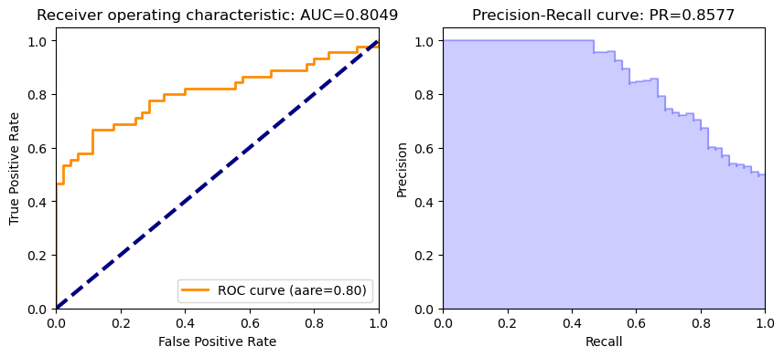

```python
def ROC_AUC(my_result,df,target):
    from sklearn.metrics import roc_curve,auc
    from sklearn.metrics import average_precision_score
    from sklearn.metrics import precision_recall_curve
    import matplotlib.pyplot as plt

    # ROC
    y_actual = df[target].as_data_frame()
    y_pred = my_result.predict(df).as_data_frame()
    fpr = list()
    tpr = list()
    roc_auc = list()
    fpr,tpr,_ = roc_curve(y_actual,y_pred)
    roc_auc = auc(fpr,tpr)

    # Precision-Recall
    average_precision = average_precision_score(y_actual,y_pred)

    print('')
    print('   * ROC curve: The ROC curve plots the true positive rate vs. the false rositive sate')
    print('')
    print('	  * The area under the curve (AUC): A value between 0.5 (random) and 1.0 (perfect), measuring the prediction accuracy')
    print('')
    print('   * Recall (R) = The number of true positives / (the number of true positives + the number of false negatives)')
    print('')

    # plotting
    plt.figure(figsize=(10,4))

    # ROC
    plt.subplot(1,2,1)
    plt.plot(fpr,tpr,color='darkorange',lw=2,label='ROC curve (aare=%0.2f)' % roc_auc)
    plt.plot([0,1],[0,1],color='navy',lw=3,linestyle='--')
    plt.xlim([0.0,1.0])
    plt.ylim([0.0,1.05])
    plt.xlabel('False Positive Rate')
    plt.ylabel('True Positive Rate')
    plt.title('Receiver operating characteristic: AUC={0:0.4f}'.format(roc_auc))
    plt.legend(loc='lower right')

    # Precision-Recall
    plt.subplot(1,2,2)
    precision,recall,_ = precision_recall_curve(y_actual,y_pred)
    plt.step(recall,precision,color='b',alpha=0.2,where='post')
    plt.fill_between(recall,precision,step='post',alpha=0.2,color='b')
    plt.xlabel('Recall')
    plt.ylabel('Precision')
    plt.ylim([0.0,1.05])
    plt.xlim([0.0,1.0])
    plt.title('Precision-Recall curve: PR={0:0.4f}'.format(average_precision))
    plt.show()
ROC_AUC(rf_v1,test_hex,'loan_default')
```

### Now the code works fine with the small dataset, we can model with the entire dataset

```python
rf_v2 = H2ORandomForestEstimator(
        model_id = 'rf_v2',
        ntrees = 300,
        nfolds=10,
        min_rows=10,
        seed=1234)
rf_v2.train(predictors,target,training_frame=train_hex)
```

```
drf Model Build progress: |██████████████████████████████████████████████████████| (done) 100%
Model Details
=============
H2ORandomForestEstimator :  Distributed Random Forest
Model Key:  rf_v2


Model Summary:
```

|  |  | number_of_trees | number_of_internal_trees | model_size_in_bytes | min_depth | max_depth | mean_depth | min_leaves | max_leaves | mean_leaves |
| --- | --- | --- | --- | --- | --- | --- | --- | --- | --- | --- |
| 0 |  | 300.0 | 300.0 | 75701.0 | 6.0 | 12.0 | 8.203333 | 12.0 | 19.0 | 15.333333 |

```
ModelMetricsRegression: drf
** Reported on train data. **

MSE: 0.14632516363338402
RMSE: 0.38252472290478695
MAE: 0.3059706238854618
RMSLE: 0.26952399146891526
Mean Residual Deviance: 0.14632516363338402

ModelMetricsRegression: drf
** Reported on cross-validation data. **

MSE: 0.15263604370884507
RMSE: 0.3906866310853816
MAE: 0.3137469408573025
RMSLE: 0.27461787107022784
Mean Residual Deviance: 0.15263604370884507

Cross-Validation Metrics Summary:
```

|  |  | mean | sd | cv_1_valid | cv_2_valid | cv_3_valid | cv_4_valid | cv_5_valid | cv_6_valid | cv_7_valid | cv_8_valid | cv_9_valid | cv_10_valid |
| --- | --- | --- | --- | --- | --- | --- | --- | --- | --- | --- | --- | --- | --- |
| 0 | mae | 0.308083 | 0.040750 | 0.235462 | 0.314159 | 0.370499 | 0.290648 | 0.338969 | 0.275648 | 0.303603 | 0.298312 | 0.290605 | 0.362924 |
| 1 | mean_residual_deviance | 0.149153 | 0.033367 | 0.091684 | 0.140227 | 0.196969 | 0.125927 | 0.167616 | 0.117743 | 0.138924 | 0.163717 | 0.153184 | 0.195536 |
| 2 | mse | 0.149153 | 0.033367 | 0.091684 | 0.140227 | 0.196969 | 0.125927 | 0.167616 | 0.117743 | 0.138924 | 0.163717 | 0.153184 | 0.195536 |
| 3 | r2 | 0.388917 | 0.144730 | 0.632570 | 0.434818 | 0.211734 | 0.495828 | 0.324575 | 0.527957 | 0.439049 | 0.235077 | 0.384530 | 0.203037 |
| 4 | residual_deviance | 0.149153 | 0.033367 | 0.091684 | 0.140227 | 0.196969 | 0.125927 | 0.167616 | 0.117743 | 0.138924 | 0.163717 | 0.153184 | 0.195536 |
| 5 | rmse | 0.383941 | 0.043996 | 0.302794 | 0.374469 | 0.443812 | 0.354862 | 0.409409 | 0.343137 | 0.372726 | 0.404620 | 0.391387 | 0.442194 |
| 6 | rmsle | 0.270745 | 0.026629 | 0.233956 | 0.266960 | 0.312038 | 0.253099 | 0.285397 | 0.235578 | 0.264282 | 0.269771 | 0.277429 | 0.308938 |

```
Scoring History:
```

|  |  | timestamp | duration | number_of_trees | training_rmse | training_mae | training_deviance |
| --- | --- | --- | --- | --- | --- | --- | --- |
| 0 |  | 2022-07-22 23:08:20 | 4.603 sec | 0.0 | NaN | NaN | NaN |
| 1 |  | 2022-07-22 23:08:20 | 4.606 sec | 1.0 | 0.391178 | 0.271263 | 0.153020 |
| 2 |  | 2022-07-22 23:08:21 | 4.608 sec | 2.0 | 0.392863 | 0.280894 | 0.154341 |
| 3 |  | 2022-07-22 23:08:21 | 4.609 sec | 3.0 | 0.402261 | 0.288576 | 0.161814 |
| 4 |  | 2022-07-22 23:08:21 | 4.610 sec | 4.0 | 0.393124 | 0.285597 | 0.154547 |
| 5 |  | 2022-07-22 23:08:21 | 4.612 sec | 5.0 | 0.404026 | 0.296192 | 0.163237 |
| 6 |  | 2022-07-22 23:08:21 | 4.614 sec | 6.0 | 0.398785 | 0.294647 | 0.159030 |
| 7 |  | 2022-07-22 23:08:21 | 4.615 sec | 7.0 | 0.390527 | 0.292621 | 0.152511 |
| 8 |  | 2022-07-22 23:08:21 | 4.617 sec | 8.0 | 0.394515 | 0.297689 | 0.155642 |
| 9 |  | 2022-07-22 23:08:21 | 4.619 sec | 9.0 | 0.392838 | 0.296210 | 0.154321 |
| 10 |  | 2022-07-22 23:08:21 | 4.620 sec | 10.0 | 0.391795 | 0.296597 | 0.153503 |
| 11 |  | 2022-07-22 23:08:21 | 4.622 sec | 11.0 | 0.390741 | 0.296656 | 0.152678 |
| 12 |  | 2022-07-22 23:08:21 | 4.624 sec | 12.0 | 0.391056 | 0.297052 | 0.152925 |
| 13 |  | 2022-07-22 23:08:21 | 4.625 sec | 13.0 | 0.391146 | 0.296782 | 0.152995 |
| 14 |  | 2022-07-22 23:08:21 | 4.627 sec | 14.0 | 0.392292 | 0.299881 | 0.153893 |
| 15 |  | 2022-07-22 23:08:21 | 4.628 sec | 15.0 | 0.393213 | 0.303359 | 0.154617 |
| 16 |  | 2022-07-22 23:08:21 | 4.630 sec | 16.0 | 0.391920 | 0.302532 | 0.153601 |
| 17 |  | 2022-07-22 23:08:21 | 4.631 sec | 17.0 | 0.392004 | 0.303629 | 0.153667 |
| 18 |  | 2022-07-22 23:08:21 | 4.633 sec | 18.0 | 0.391488 | 0.302973 | 0.153263 |
| 19 |  | 2022-07-22 23:08:21 | 4.635 sec | 19.0 | 0.392522 | 0.308362 | 0.154073 |

```
See the whole table with table.as_data_frame()

Variable Importances:
```

|  | variable | relative_importance | scaled_importance | percentage |
| --- | --- | --- | --- | --- |
| 0 | PA022 | 2641.428467 | 1.000000 | 0.251192 |
| 1 | PA029 | 1821.629761 | 0.689638 | 0.173232 |
| 2 | TD009 | 1627.260620 | 0.616053 | 0.154748 |
| 3 | TD005 | 849.664062 | 0.321668 | 0.080800 |
| 4 | PA023 | 704.871094 | 0.266852 | 0.067031 |
| 5 | TD014 | 672.202209 | 0.254484 | 0.063924 |
| 6 | TD010 | 627.600037 | 0.237599 | 0.059683 |
| 7 | CR009 | 381.252167 | 0.144336 | 0.036256 |
| 8 | AP001 | 352.384003 | 0.133407 | 0.033511 |
| 9 | CR019 | 213.891876 | 0.080976 | 0.020340 |
| 10 | TD001 | 212.171585 | 0.080325 | 0.020177 |
| 11 | TD006 | 182.537842 | 0.069106 | 0.017359 |
| 12 | CR015 | 122.234489 | 0.046276 | 0.011624 |
| 13 | AP008 | 82.051773 | 0.031063 | 0.007803 |
| 14 | AP003 | 24.400253 | 0.009238 | 0.002320 |

```python
createGains(rf_v2)
```

```
drf prediction progress: |███████████████████████████████████████████████████████| (done) 100%
```

| decile | count | actual | non_actual | cum_count | cum_actual | cum_non_actual | percent_cum_actual | percent_cum_non_actual | if_random | lift | K_S | gain |
| --- | --- | --- | --- | --- | --- | --- | --- | --- | --- | --- | --- | --- |
| 0 | 9 | 9 | 0 | 9 | 9 | 0 | 0.20 | 0.00 | 4.5 | 2.00 | 20.0 | 100.00 |
| 1 | 9 | 9 | 0 | 18 | 18 | 0 | 0.40 | 0.00 | 9.0 | 2.00 | 40.0 | 100.00 |
| 2 | 9 | 7 | 2 | 27 | 25 | 2 | 0.56 | 0.04 | 13.5 | 1.85 | 52.0 | 92.59 |
| 3 | 9 | 5 | 4 | 36 | 30 | 6 | 0.67 | 0.13 | 18.0 | 1.67 | 54.0 | 83.33 |
| 4 | 9 | 2 | 7 | 45 | 32 | 13 | 0.71 | 0.29 | 22.5 | 1.42 | 42.0 | 71.11 |
| 5 | 9 | 4 | 5 | 54 | 36 | 18 | 0.80 | 0.40 | 27.0 | 1.33 | 40.0 | 66.67 |
| 6 | 9 | 2 | 7 | 63 | 38 | 25 | 0.84 | 0.56 | 31.5 | 1.21 | 28.0 | 60.32 |
| 7 | 9 | 2 | 7 | 72 | 40 | 32 | 0.89 | 0.71 | 36.0 | 1.11 | 18.0 | 55.56 |
| 8 | 9 | 2 | 7 | 81 | 42 | 39 | 0.93 | 0.87 | 40.5 | 1.04 | 6.0 | 51.85 |
| 9 | 9 | 3 | 6 | 90 | 45 | 45 | 1.00 | 1.00 | 45.0 | 1.00 | 0.0 | 50.00 |

```python
predictions = rf_v2.predict(test_hex)
predictions.head()
test_scores = test_hex['loan_default'].cbind(predictions).as_data_frame()
test_scores.rename(columns = {'loan_default':'actual'}, inplace=True)
test_scores.head()
```

```
drf prediction progress: |███████████████████████████████████████████████████████| (done) 100%
```

|  | actual | predict |
| --- | --- | --- |
| 0 | 1 | 0.290164 |
| 1 | 0 | 0.233698 |
| 2 | 1 | 0.945518 |
| 3 | 0 | 0.164109 |
| 4 | 1 | 0.639218 |

```python
# ROC
from sklearn.metrics import roc_curve,roc_auc_score, auc
from sklearn.metrics import average_precision_score, precision_recall_curve

dd = test_scores
RF_roc_auc_value = roc_auc_score(dd['actual'],dd['predict'])
RF_roc_auc_value
```

```
0.8014814814814815
```

### rf_v3

```python
rf_v3 = H2ORandomForestEstimator(
        model_id = 'rf_v3',
        ntrees = 30,
        nfolds=10,
        min_rows=10,
        balance_classes = True,
        seed=1234)
rf_v3.train(predictors,target,training_frame=train_hex)
```

```
drf Model Build progress: |██████████████████████████████████████████████████████| (done) 100%
Model Details
=============
H2ORandomForestEstimator :  Distributed Random Forest
Model Key:  rf_v3


Model Summary:
```

|  |  | number_of_trees | number_of_internal_trees | model_size_in_bytes | min_depth | max_depth | mean_depth | min_leaves | max_leaves | mean_leaves |
| --- | --- | --- | --- | --- | --- | --- | --- | --- | --- | --- |
| 0 |  | 30.0 | 30.0 | 7626.0 | 6.0 | 10.0 | 8.2 | 13.0 | 18.0 | 15.566667 |

```
ModelMetricsRegression: drf
** Reported on train data. **

MSE: 0.15226628199699005
RMSE: 0.39021312381439716
MAE: 0.3104089108435177
RMSLE: 0.2741076676137261
Mean Residual Deviance: 0.15226628199699005

ModelMetricsRegression: drf
** Reported on cross-validation data. **

MSE: 0.15395888156087362
RMSE: 0.3923759441669094
MAE: 0.3131605089532846
RMSLE: 0.27574799817497164
Mean Residual Deviance: 0.15395888156087362

Cross-Validation Metrics Summary:
```

|  |  | mean | sd | cv_1_valid | cv_2_valid | cv_3_valid | cv_4_valid | cv_5_valid | cv_6_valid | cv_7_valid | cv_8_valid | cv_9_valid | cv_10_valid |
| --- | --- | --- | --- | --- | --- | --- | --- | --- | --- | --- | --- | --- | --- |
| 0 | mae | 0.307625 | 0.041765 | 0.232399 | 0.318274 | 0.363783 | 0.286170 | 0.344423 | 0.269114 | 0.313074 | 0.296543 | 0.289971 | 0.362501 |
| 1 | mean_residual_deviance | 0.150384 | 0.034962 | 0.089375 | 0.146218 | 0.195353 | 0.120496 | 0.176390 | 0.114289 | 0.146218 | 0.161962 | 0.156474 | 0.197060 |
| 2 | mse | 0.150384 | 0.034962 | 0.089375 | 0.146218 | 0.195353 | 0.120496 | 0.176390 | 0.114289 | 0.146218 | 0.161962 | 0.156474 | 0.197060 |
| 3 | r2 | 0.384030 | 0.149835 | 0.641823 | 0.410671 | 0.218202 | 0.517573 | 0.289216 | 0.541805 | 0.409598 | 0.243277 | 0.371308 | 0.196823 |
| 4 | residual_deviance | 0.150384 | 0.034962 | 0.089375 | 0.146218 | 0.195353 | 0.120496 | 0.176390 | 0.114289 | 0.146218 | 0.161962 | 0.156474 | 0.197060 |
| 5 | rmse | 0.385282 | 0.046443 | 0.298956 | 0.382385 | 0.441988 | 0.347125 | 0.419989 | 0.338066 | 0.382385 | 0.402445 | 0.395568 | 0.443915 |
| 6 | rmsle | 0.271681 | 0.028571 | 0.230845 | 0.271280 | 0.310729 | 0.247897 | 0.292696 | 0.231941 | 0.270420 | 0.269948 | 0.280936 | 0.310118 |

```
Scoring History:
```

|  |  | timestamp | duration | number_of_trees | training_rmse | training_mae | training_deviance |
| --- | --- | --- | --- | --- | --- | --- | --- |
| 0 |  | 2022-07-22 23:09:36 | 0.230 sec | 0.0 | NaN | NaN | NaN |
| 1 |  | 2022-07-22 23:09:36 | 0.232 sec | 1.0 | 0.391178 | 0.271263 | 0.153020 |
| 2 |  | 2022-07-22 23:09:36 | 0.234 sec | 2.0 | 0.392863 | 0.280894 | 0.154341 |
| 3 |  | 2022-07-22 23:09:36 | 0.235 sec | 3.0 | 0.402261 | 0.288576 | 0.161814 |
| 4 |  | 2022-07-22 23:09:36 | 0.237 sec | 4.0 | 0.393124 | 0.285597 | 0.154547 |
| 5 |  | 2022-07-22 23:09:36 | 0.238 sec | 5.0 | 0.404026 | 0.296192 | 0.163237 |
| 6 |  | 2022-07-22 23:09:36 | 0.240 sec | 6.0 | 0.398785 | 0.294647 | 0.159030 |
| 7 |  | 2022-07-22 23:09:36 | 0.242 sec | 7.0 | 0.390527 | 0.292621 | 0.152511 |
| 8 |  | 2022-07-22 23:09:36 | 0.243 sec | 8.0 | 0.394515 | 0.297689 | 0.155642 |
| 9 |  | 2022-07-22 23:09:36 | 0.244 sec | 9.0 | 0.392838 | 0.296210 | 0.154321 |
| 10 |  | 2022-07-22 23:09:36 | 0.246 sec | 10.0 | 0.391795 | 0.296597 | 0.153503 |
| 11 |  | 2022-07-22 23:09:36 | 0.248 sec | 11.0 | 0.390741 | 0.296656 | 0.152678 |
| 12 |  | 2022-07-22 23:09:36 | 0.250 sec | 12.0 | 0.391056 | 0.297052 | 0.152925 |
| 13 |  | 2022-07-22 23:09:36 | 0.251 sec | 13.0 | 0.391146 | 0.296782 | 0.152995 |
| 14 |  | 2022-07-22 23:09:36 | 0.253 sec | 14.0 | 0.392292 | 0.299881 | 0.153893 |
| 15 |  | 2022-07-22 23:09:36 | 0.254 sec | 15.0 | 0.393213 | 0.303359 | 0.154617 |
| 16 |  | 2022-07-22 23:09:36 | 0.255 sec | 16.0 | 0.391920 | 0.302532 | 0.153601 |
| 17 |  | 2022-07-22 23:09:36 | 0.257 sec | 17.0 | 0.392004 | 0.303629 | 0.153667 |
| 18 |  | 2022-07-22 23:09:36 | 0.258 sec | 18.0 | 0.391488 | 0.302973 | 0.153263 |
| 19 |  | 2022-07-22 23:09:36 | 0.260 sec | 19.0 | 0.392522 | 0.308362 | 0.154073 |

```
See the whole table with table.as_data_frame()

Variable Importances:
```

|  | variable | relative_importance | scaled_importance | percentage |
| --- | --- | --- | --- | --- |
| 0 | PA022 | 240.613800 | 1.000000 | 0.228451 |
| 1 | PA029 | 210.432007 | 0.874563 | 0.199795 |
| 2 | TD009 | 179.509613 | 0.746049 | 0.170436 |
| 3 | TD005 | 95.213181 | 0.395710 | 0.090400 |
| 4 | PA023 | 64.827820 | 0.269427 | 0.061551 |
| 5 | TD010 | 53.492680 | 0.222318 | 0.050789 |
| 6 | CR009 | 51.438393 | 0.213780 | 0.048838 |
| 7 | TD014 | 40.996136 | 0.170381 | 0.038924 |
| 8 | AP001 | 40.269207 | 0.167360 | 0.038234 |
| 9 | TD006 | 25.799448 | 0.107223 | 0.024495 |
| 10 | TD001 | 16.143375 | 0.067092 | 0.015327 |
| 11 | CR019 | 15.694350 | 0.065226 | 0.014901 |
| 12 | AP008 | 12.630766 | 0.052494 | 0.011992 |
| 13 | AP003 | 3.276609 | 0.013618 | 0.003111 |
| 14 | CR015 | 2.902010 | 0.012061 | 0.002755 |

```
drf prediction progress: |███████████████████████████████████████████████████████| (done) 100%

   * ROC curve: The ROC curve plots the true positive rate vs. the false rositive sate

	  * The area under the curve (AUC): A value between 0.5 (random) and 1.0 (perfect), measuring the prediction accuracy

   * Recall (R) = The number of true positives / (the number of true positives + the number of false negatives)
```

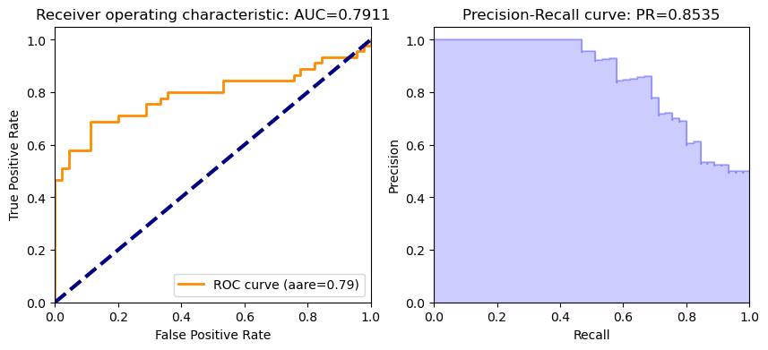

```python
ROC_AUC(rf_v3,test_hex,'loan_default')
```

```python
from imblearn.datasets import make_imbalance
X_rs, y_rs = make_imbalance(X_dd, y_dd,
                            sampling_strategy={1:pd.DataFrame(y_dd).value_counts()[1] , 0:  pd.DataFrame(y_dd).value_counts()[1]*2},
                            random_state=0)
X_rs = pd.DataFrame(X_rs)
y_rs = pd.DataFrame(y_rs)
```

```python
data = pd.concat([pd.DataFrame(X_dd), pd.DataFrame(y_dd)], axis=1)
ff = features.copy()
ff.append('loan_default')
data.colums = ff
f = features.copy()
f.append('loan_default')
data.columns = f
y_rs = data[data['loan_default']==1]
X_rs = data[data['loan_default']==0].sample(n=pd.DataFrame(y_dd).value_counts()[1]*2)
smpl = pd.concat([X_rs,y_rs])
smpl_hex = h2o.H2OFrame(smpl)
```

```
Parse progress: |████████████████████████████████████████████████████████████████| (done) 100%
```

```python
rf_v4 = H2ORandomForestEstimator(
        model_id = 'rf_v4',
        ntrees = 50,
        nfolds=10,
        min_rows=5,
        seed=23)
rf_v4.train(predictors,target,training_frame=smpl_hex)
```

```
drf Model Build progress: |██████████████████████████████████████████████████████| (done) 100%
Model Details
=============
H2ORandomForestEstimator :  Distributed Random Forest
Model Key:  rf_v4


Model Summary:
```

|  |  | number_of_trees | number_of_internal_trees | model_size_in_bytes | min_depth | max_depth | mean_depth | min_leaves | max_leaves | mean_leaves |
| --- | --- | --- | --- | --- | --- | --- | --- | --- | --- | --- |
| 0 |  | 50.0 | 50.0 | 40451.0 | 10.0 | 20.0 | 13.78 | 51.0 | 66.0 | 59.34 |

```
ModelMetricsRegression: drf
** Reported on train data. **

MSE: 0.2209919432172515
RMSE: 0.47009780175751886
MAE: 0.4212582464601876
RMSLE: 0.3307717797041364
Mean Residual Deviance: 0.2209919432172515

ModelMetricsRegression: drf
** Reported on cross-validation data. **

MSE: 0.22116402810997013
RMSE: 0.47028079708826104
MAE: 0.42492688653081473
RMSLE: 0.3308060232577596
Mean Residual Deviance: 0.22116402810997013

Cross-Validation Metrics Summary:
```

|  |  | mean | sd | cv_1_valid | cv_2_valid | cv_3_valid | cv_4_valid | cv_5_valid | cv_6_valid | cv_7_valid | cv_8_valid | cv_9_valid | cv_10_valid |
| --- | --- | --- | --- | --- | --- | --- | --- | --- | --- | --- | --- | --- | --- |
| 0 | mae | 0.424915 | 0.020328 | 0.422011 | 0.409796 | 0.399058 | 0.460553 | 0.435678 | 0.411479 | 0.441822 | 0.421037 | 0.445585 | 0.402133 |
| 1 | mean_residual_deviance | 0.221443 | 0.024760 | 0.217361 | 0.199815 | 0.189760 | 0.268997 | 0.229836 | 0.208625 | 0.243764 | 0.214174 | 0.243204 | 0.198894 |
| 2 | mse | 0.221443 | 0.024760 | 0.217361 | 0.199815 | 0.189760 | 0.268997 | 0.229836 | 0.208625 | 0.243764 | 0.214174 | 0.243204 | 0.198894 |
| 3 | r2 | -0.009528 | 0.079748 | 0.001943 | -0.112889 | 0.096383 | -0.104727 | -0.057205 | 0.125797 | -0.061726 | 0.043148 | -0.008928 | -0.017073 |
| 4 | residual_deviance | 0.221443 | 0.024760 | 0.217361 | 0.199815 | 0.189760 | 0.268997 | 0.229836 | 0.208625 | 0.243764 | 0.214174 | 0.243204 | 0.198894 |
| 5 | rmse | 0.469930 | 0.026001 | 0.466220 | 0.447006 | 0.435614 | 0.518649 | 0.479412 | 0.456754 | 0.493724 | 0.462790 | 0.493157 | 0.445976 |
| 6 | rmsle | 0.330515 | 0.013173 | 0.329024 | 0.327686 | 0.311825 | 0.352325 | 0.339392 | 0.311993 | 0.344703 | 0.325994 | 0.337511 | 0.324692 |

```
Scoring History:
```

|  |  | timestamp | duration | number_of_trees | training_rmse | training_mae | training_deviance |
| --- | --- | --- | --- | --- | --- | --- | --- |
| 0 |  | 2022-07-22 23:11:38 | 0.651 sec | 0.0 | NaN | NaN | NaN |
| 1 |  | 2022-07-22 23:11:38 | 0.655 sec | 1.0 | 0.538086 | 0.410565 | 0.289537 |
| 2 |  | 2022-07-22 23:11:38 | 0.657 sec | 2.0 | 0.518975 | 0.404503 | 0.269335 |
| 3 |  | 2022-07-22 23:11:38 | 0.661 sec | 3.0 | 0.510435 | 0.400671 | 0.260543 |
| 4 |  | 2022-07-22 23:11:38 | 0.664 sec | 4.0 | 0.513430 | 0.413127 | 0.263610 |
| 5 |  | 2022-07-22 23:11:38 | 0.666 sec | 5.0 | 0.505548 | 0.411192 | 0.255579 |
| 6 |  | 2022-07-22 23:11:38 | 0.668 sec | 6.0 | 0.498574 | 0.407327 | 0.248576 |
| 7 |  | 2022-07-22 23:11:38 | 0.671 sec | 7.0 | 0.493645 | 0.405893 | 0.243686 |
| 8 |  | 2022-07-22 23:11:38 | 0.673 sec | 8.0 | 0.491235 | 0.407982 | 0.241312 |
| 9 |  | 2022-07-22 23:11:38 | 0.676 sec | 9.0 | 0.485798 | 0.409314 | 0.236000 |
| 10 |  | 2022-07-22 23:11:38 | 0.679 sec | 10.0 | 0.481005 | 0.409281 | 0.231365 |
| 11 |  | 2022-07-22 23:11:38 | 0.681 sec | 11.0 | 0.476652 | 0.410040 | 0.227197 |
| 12 |  | 2022-07-22 23:11:38 | 0.684 sec | 12.0 | 0.476190 | 0.410970 | 0.226757 |
| 13 |  | 2022-07-22 23:11:38 | 0.687 sec | 13.0 | 0.476396 | 0.411399 | 0.226953 |
| 14 |  | 2022-07-22 23:11:38 | 0.690 sec | 14.0 | 0.474926 | 0.411077 | 0.225555 |
| 15 |  | 2022-07-22 23:11:38 | 0.693 sec | 15.0 | 0.473538 | 0.412427 | 0.224239 |
| 16 |  | 2022-07-22 23:11:38 | 0.695 sec | 16.0 | 0.474815 | 0.414982 | 0.225450 |
| 17 |  | 2022-07-22 23:11:38 | 0.699 sec | 17.0 | 0.475372 | 0.416282 | 0.225978 |
| 18 |  | 2022-07-22 23:11:38 | 0.702 sec | 18.0 | 0.475554 | 0.416758 | 0.226152 |
| 19 |  | 2022-07-22 23:11:38 | 0.704 sec | 19.0 | 0.475846 | 0.417498 | 0.226430 |

```
See the whole table with table.as_data_frame()

Variable Importances:
```

|  | variable | relative_importance | scaled_importance | percentage |
| --- | --- | --- | --- | --- |
| 0 | TD009 | 229.959015 | 1.000000 | 0.110383 |
| 1 | AP001 | 216.055267 | 0.939538 | 0.103709 |
| 2 | CR009 | 212.349503 | 0.923423 | 0.101930 |
| 3 | TD014 | 179.756485 | 0.781689 | 0.086285 |
| 4 | TD005 | 179.223343 | 0.779371 | 0.086029 |
| 5 | CR019 | 141.693619 | 0.616169 | 0.068014 |
| 6 | TD001 | 140.115204 | 0.609305 | 0.067257 |
| 7 | PA022 | 117.638130 | 0.511561 | 0.056467 |
| 8 | TD010 | 113.051292 | 0.491615 | 0.054266 |
| 9 | TD006 | 103.708504 | 0.450987 | 0.049781 |
| 10 | AP008 | 101.997498 | 0.443546 | 0.048960 |
| 11 | PA023 | 99.129562 | 0.431075 | 0.047583 |
| 12 | PA029 | 97.496506 | 0.423973 | 0.046799 |
| 13 | CR015 | 78.061371 | 0.339458 | 0.037470 |
| 14 | AP003 | 73.056419 | 0.317693 | 0.035068 |

```
drf prediction progress: |███████████████████████████████████████████████████████| (done) 100%

   * ROC curve: The ROC curve plots the true positive rate vs. the false rositive sate

	  * The area under the curve (AUC): A value between 0.5 (random) and 1.0 (perfect), measuring the prediction accuracy

   * Recall (R) = The number of true positives / (the number of true positives + the number of false negatives)
```

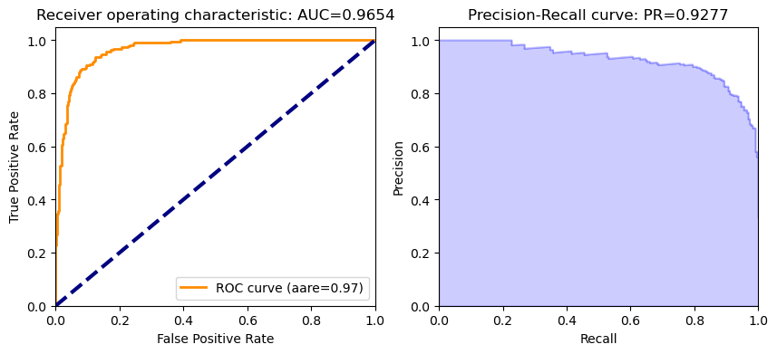

```python
ROC_AUC(rf_v4,smpl_hex,'loan_default')
```

### Automl

```python
from h2o.automl import H2OAutoML
# Run AutoML for 20 base models (limited to 1 hour max runtime by default)
aml = H2OAutoML(max_models=20, seed=1)
aml.train(x=predictors, y=target, training_frame=train_hex)

# View the AutoML Leaderboard
lb = aml.leaderboard
lb.head(rows=lb.nrows)  # Print all rows instead of default (10 rows)
```

[output not shown]

| model_id | rmse | mse | mae | rmsle | mean_residual_deviance |
| --- | --- | --- | --- | --- | --- |
| StackedEnsemble_BestOfFamily_1_AutoML_1_20220722_215103 | 0.37454 | 0.14028 | 0.293801 | 0.263884 | 0.14028 |
| StackedEnsemble_AllModels_1_AutoML_1_20220722_215103 | 0.375713 | 0.14116 | 0.294489 | 0.264708 | 0.14116 |
| XRT_1_AutoML_1_20220722_215103 | 0.38082 | 0.145024 | 0.275806 | 0.267292 | 0.145024 |
| DRF_1_AutoML_1_20220722_215103 | 0.383074 | 0.146746 | 0.272773 | 0.268374 | 0.146746 |
| DeepLearning_grid_2_AutoML_1_20220722_215103_model_2 | 0.386129 | 0.149096 | 0.307101 | 0.274065 | 0.149096 |
| GBM_grid_1_AutoML_1_20220722_215103_model_2 | 0.387297 | 0.149999 | 0.297239 | 0.271196 | 0.149999 |
| DeepLearning_grid_2_AutoML_1_20220722_215103_model_1 | 0.387886 | 0.150456 | 0.26872 | 0.271139 | 0.150456 |
| GBM_grid_1_AutoML_1_20220722_215103_model_1 | 0.388388 | 0.150845 | 0.309098 | 0.273242 | 0.150845 |
| GBM_grid_1_AutoML_1_20220722_215103_model_3 | 0.389249 | 0.151514 | 0.303741 | 0.273541 | 0.151514 |
| GBM_3_AutoML_1_20220722_215103 | 0.389587 | 0.151778 | 0.297687 | 0.274592 | 0.151778 |
| GBM_2_AutoML_1_20220722_215103 | 0.390493 | 0.152485 | 0.297958 | 0.275793 | 0.152485 |
| GBM_4_AutoML_1_20220722_215103 | 0.391807 | 0.153512 | 0.296521 | 0.276513 | 0.153512 |
| GBM_grid_1_AutoML_1_20220722_215103_model_5 | 0.393269 | 0.154661 | 0.302834 | 0.278295 | 0.154661 |
| GBM_grid_1_AutoML_1_20220722_215103_model_4 | 0.394961 | 0.155994 | 0.326767 | 0.277959 | 0.155994 |
| DeepLearning_grid_3_AutoML_1_20220722_215103_model_1 | 0.396411 | 0.157142 | 0.285487 | 0.279147 | 0.157142 |
| DeepLearning_grid_3_AutoML_1_20220722_215103_model_2 | 0.398815 | 0.159054 | 0.323914 | 0.28136 | 0.159054 |
| GBM_5_AutoML_1_20220722_215103 | 0.398889 | 0.159112 | 0.29891 | 0.279701 | 0.159112 |
| DeepLearning_grid_1_AutoML_1_20220722_215103_model_2 | 0.406981 | 0.165633 | 0.303702 | 0.278919 | 0.165633 |
| DeepLearning_grid_1_AutoML_1_20220722_215103_model_1 | 0.412608 | 0.170246 | 0.319176 | 0.281964 | 0.170246 |
| GLM_1_AutoML_1_20220722_215103 | 0.415438 | 0.172589 | 0.373976 | 0.289034 | 0.172589 |
| DeepLearning_1_AutoML_1_20220722_215103 | 0.430695 | 0.185498 | 0.359907 | 0.301954 | 0.185498 |
| GBM_1_AutoML_1_20220722_215103 | 0.450198 | 0.202678 | 0.42111 | 0.316527 | 0.202678 |

#### Method 2: OverSampling

Back to Table of Content

- Thoughts: SMOTE-(Synthetic Minority Oversampling TEchnique) consists of synthesizing elements for the minority class, based on those that already exist. It works randomly picingk a point from the minority class and computing the k-nearest neighbors for this point. The synthetic points are added between the chosen point and its neighbors.

```
RandomOverSampler Counter({0: 1200, 1: 1200})
```

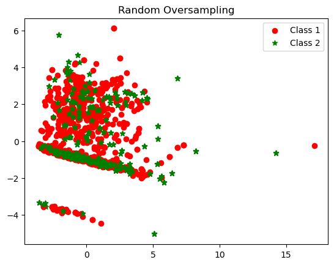

```
SMOTE Counter({0: 1200, 1: 1200})
```

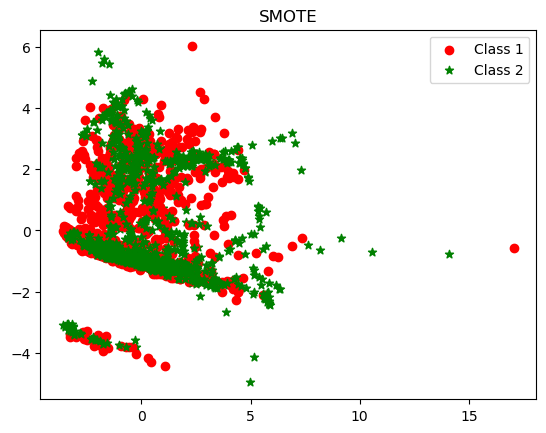

```
ADASYN Counter({0: 1165, 1: 1127})
```

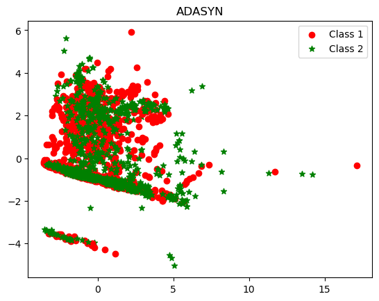

```python
from imblearn.over_sampling import (RandomOverSampler,
                                    SMOTE,
                                    ADASYN)
# RandomOverSampler
  # With over-sampling methods, the number of samples in a class
  # should be greater or equal to the original number of samples.
sampler = RandomOverSampler(sampling_strategy={1: 1200, 0: 1200})
X_ros, y_ros = sampler.fit_resample(X_dd, y_dd)
print('RandomOverSampler {}'.format(Counter(y_ros)))
plot_this(X_ros,y_ros, 'Random Oversampling')

# SMOTE
sampler = SMOTE(sampling_strategy={1: 1200, 0: 1200})
X_sm, y_sm = sampler.fit_resample(X_dd, y_dd)
print('SMOTE {}'.format(Counter(y_sm)))
plot_this(X_sm,y_sm,'SMOTE')

# ADASYN
sampler = ADASYN(sampling_strategy={1: 1200, 0: 1200})
X_ad, y_ad = sampler.fit_resample(X_dd, y_dd)
print('ADASYN {}'.format(Counter(y_ad)))
plot_this(X_ad, y_ad, 'ADASYN')
```

```python
# take NearMiss as an example
import h2o
h2o.init()
df = pd.concat([pd.DataFrame(X_ad), pd.DataFrame(y_ad)], axis=1)
df.head()
```

```
Checking whether there is an H2O instance running at http://localhost:54321 . connected.
```

[output not shown]

|  | 0 | 1 | 2 | 3 | 4 | 5 | 6 | 7 | 8 | 9 | 10 | 11 | 12 | 13 | 14 | 0 |
| --- | --- | --- | --- | --- | --- | --- | --- | --- | --- | --- | --- | --- | --- | --- | --- | --- |
| 0 | -0.521643 | 0.823712 | 1.443939 | -0.287941 | 0.070577 | -1.248989 | -0.513498 | -0.431024 | -0.570474 | 0.004168 | 0.143045 | -0.246233 | -0.352589 | -0.520575 | -0.642998 | 0 |
| 1 | -1.228018 | -0.847725 | -0.852239 | -0.416455 | -1.754303 | -0.951040 | -0.286541 | -0.187708 | 1.335682 | -0.547853 | -0.927695 | -0.246233 | -0.601792 | -0.520575 | -0.642998 | 0 |
| 2 | 1.456205 | -0.847725 | 1.443939 | -0.221948 | 0.983017 | 1.432556 | 2.109121 | 2.380626 | 1.386923 | 2.212251 | 2.998351 | 1.879113 | 2.388645 | 1.005763 | 0.956565 | 1 |
| 3 | -0.662918 | 0.823712 | -0.852239 | 1.397332 | 0.070577 | 1.432556 | 1.907381 | 2.164345 | 0.802778 | 2.764272 | 1.927611 | 1.170664 | 0.893427 | 0.496984 | 0.156784 | 0 |
| 4 | -0.662918 | 0.823712 | -0.852239 | -0.481662 | -2.666743 | -1.248989 | -0.513498 | -0.431024 | -0.570474 | 0.004168 | -0.213868 | -0.246233 | -0.103386 | -0.520575 | -0.642998 | 0 |

```python
f = features.copy()
f.append('loan_default')
df.columns = f
from sklearn.model_selection import train_test_split
train,test = train_test_split(df, test_size=0.2, random_state=23)
df_hex = h2o.H2OFrame(df)
train_hex = h2o.H2OFrame(train)
test_hex = h2o.H2OFrame(test)
```

```
Parse progress: |████████████████████████████████████████████████████████████████| (done) 100%
Parse progress: |████████████████████████████████████████████████████████████████| (done) 100%
Parse progress: |████████████████████████████████████████████████████████████████| (done) 100%
```

```python
predictors = features
target = 'loan_default'
```

```python
from h2o.estimators.random_forest import H2ORandomForestEstimator
rf_v1 = H2ORandomForestEstimator(
        model_id = 'rf_v1',
        ntrees = 60,
        nfolds=10,
        min_rows=1,
        seed=23)
rf_v1.train(predictors,target,training_frame=train_hex)
```

```
drf Model Build progress: |██████████████████████████████████████████████████████| (done) 100%
Model Details
=============
H2ORandomForestEstimator :  Distributed Random Forest
Model Key:  rf_v1


Model Summary:
```

|  |  | number_of_trees | number_of_internal_trees | model_size_in_bytes | min_depth | max_depth | mean_depth | min_leaves | max_leaves | mean_leaves |
| --- | --- | --- | --- | --- | --- | --- | --- | --- | --- | --- |
| 0 |  | 60.0 | 60.0 | 205367.0 | 16.0 | 20.0 | 19.116667 | 241.0 | 294.0 | 267.3 |

```
ModelMetricsRegression: drf
** Reported on train data. **

MSE: 0.10864809300015296
RMSE: 0.3296181017483005
MAE: 0.26985468262148743
RMSLE: 0.23805068132290252
Mean Residual Deviance: 0.10864809300015296

ModelMetricsRegression: drf
** Reported on cross-validation data. **

MSE: 0.10828549062850727
RMSE: 0.32906760799037527
MAE: 0.2774913250470535
RMSLE: 0.23744999876549294
Mean Residual Deviance: 0.10828549062850727

Cross-Validation Metrics Summary:
```

|  |  | mean | sd | cv_1_valid | cv_2_valid | cv_3_valid | cv_4_valid | cv_5_valid | cv_6_valid | cv_7_valid | cv_8_valid | cv_9_valid | cv_10_valid |
| --- | --- | --- | --- | --- | --- | --- | --- | --- | --- | --- | --- | --- | --- |
| 0 | mae | 0.277191 | 0.011223 | 0.274242 | 0.272745 | 0.293327 | 0.264962 | 0.294370 | 0.272962 | 0.260753 | 0.272066 | 0.285744 | 0.280743 |
| 1 | mean_residual_deviance | 0.108093 | 0.008052 | 0.110435 | 0.101635 | 0.121208 | 0.100076 | 0.116473 | 0.106179 | 0.096412 | 0.104344 | 0.116764 | 0.107403 |
| 2 | mse | 0.108093 | 0.008052 | 0.110435 | 0.101635 | 0.121208 | 0.100076 | 0.116473 | 0.106179 | 0.096412 | 0.104344 | 0.116764 | 0.107403 |
| 3 | r2 | 0.563908 | 0.035046 | 0.554240 | 0.591719 | 0.499804 | 0.597825 | 0.532116 | 0.573307 | 0.611883 | 0.582161 | 0.529464 | 0.566563 |
| 4 | residual_deviance | 0.108093 | 0.008052 | 0.110435 | 0.101635 | 0.121208 | 0.100076 | 0.116473 | 0.106179 | 0.096412 | 0.104344 | 0.116764 | 0.107403 |
| 5 | rmse | 0.328571 | 0.012210 | 0.332317 | 0.318802 | 0.348150 | 0.316348 | 0.341282 | 0.325851 | 0.310503 | 0.323023 | 0.341707 | 0.327725 |
| 6 | rmsle | 0.236921 | 0.010489 | 0.231080 | 0.233970 | 0.260298 | 0.224180 | 0.245414 | 0.236833 | 0.224104 | 0.237648 | 0.237741 | 0.237941 |

```
Scoring History:
```

|  |  | timestamp | duration | number_of_trees | training_rmse | training_mae | training_deviance |
| --- | --- | --- | --- | --- | --- | --- | --- |
| 0 |  | 2022-07-22 23:28:10 | 2.248 sec | 0.0 | NaN | NaN | NaN |
| 1 |  | 2022-07-22 23:28:10 | 2.255 sec | 1.0 | 0.527276 | 0.279476 | 0.278020 |
| 2 |  | 2022-07-22 23:28:10 | 2.260 sec | 2.0 | 0.516401 | 0.286574 | 0.266670 |
| 3 |  | 2022-07-22 23:28:10 | 2.266 sec | 3.0 | 0.481145 | 0.270505 | 0.231501 |
| 4 |  | 2022-07-22 23:28:10 | 2.271 sec | 4.0 | 0.464860 | 0.271951 | 0.216095 |
| 5 |  | 2022-07-22 23:28:10 | 2.276 sec | 5.0 | 0.448156 | 0.268952 | 0.200844 |
| 6 |  | 2022-07-22 23:28:10 | 2.282 sec | 6.0 | 0.430247 | 0.265498 | 0.185112 |
| 7 |  | 2022-07-22 23:28:10 | 2.287 sec | 7.0 | 0.422169 | 0.267591 | 0.178227 |
| 8 |  | 2022-07-22 23:28:10 | 2.292 sec | 8.0 | 0.413238 | 0.269668 | 0.170766 |
| 9 |  | 2022-07-22 23:28:10 | 2.297 sec | 9.0 | 0.406105 | 0.269610 | 0.164921 |
| 10 |  | 2022-07-22 23:28:10 | 2.302 sec | 10.0 | 0.393498 | 0.266372 | 0.154841 |
| 11 |  | 2022-07-22 23:28:10 | 2.307 sec | 11.0 | 0.386076 | 0.265346 | 0.149055 |
| 12 |  | 2022-07-22 23:28:10 | 2.312 sec | 12.0 | 0.377940 | 0.264003 | 0.142839 |
| 13 |  | 2022-07-22 23:28:10 | 2.316 sec | 13.0 | 0.373465 | 0.265184 | 0.139476 |
| 14 |  | 2022-07-22 23:28:10 | 2.322 sec | 14.0 | 0.371823 | 0.266198 | 0.138252 |
| 15 |  | 2022-07-22 23:28:10 | 2.328 sec | 15.0 | 0.369500 | 0.267891 | 0.136530 |
| 16 |  | 2022-07-22 23:28:10 | 2.333 sec | 16.0 | 0.364002 | 0.266779 | 0.132498 |
| 17 |  | 2022-07-22 23:28:10 | 2.338 sec | 17.0 | 0.362058 | 0.266185 | 0.131086 |
| 18 |  | 2022-07-22 23:28:10 | 2.344 sec | 18.0 | 0.358876 | 0.266640 | 0.128792 |
| 19 |  | 2022-07-22 23:28:10 | 2.350 sec | 19.0 | 0.356356 | 0.265845 | 0.126990 |

```
See the whole table with table.as_data_frame()

Variable Importances:
```

|  | variable | relative_importance | scaled_importance | percentage |
| --- | --- | --- | --- | --- |
| 0 | TD010 | 1575.163574 | 1.000000 | 0.089558 |
| 1 | TD006 | 1554.400513 | 0.986818 | 0.088377 |
| 2 | CR019 | 1513.155396 | 0.960634 | 0.086032 |
| 3 | TD001 | 1437.371826 | 0.912522 | 0.081724 |
| 4 | AP001 | 1385.630737 | 0.879674 | 0.078782 |
| 5 | TD009 | 1302.773926 | 0.827072 | 0.074071 |
| 6 | TD014 | 1278.005249 | 0.811348 | 0.072663 |
| 7 | AP008 | 1257.502563 | 0.798331 | 0.071497 |
| 8 | TD005 | 1243.836060 | 0.789655 | 0.070720 |
| 9 | CR015 | 1099.615967 | 0.698096 | 0.062520 |
| 10 | CR009 | 1033.454590 | 0.656094 | 0.058758 |
| 11 | AP003 | 842.476257 | 0.534850 | 0.047900 |
| 12 | PA022 | 792.485352 | 0.503113 | 0.045058 |
| 13 | PA023 | 653.002197 | 0.414562 | 0.037127 |
| 14 | PA029 | 619.324829 | 0.393181 | 0.035213 |

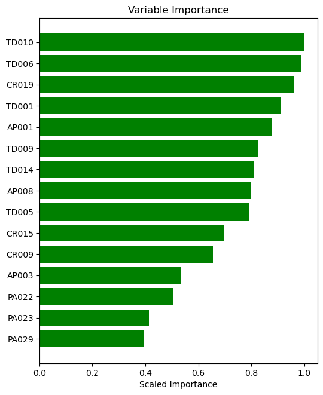

```python
def VarImp(model_name):

    from sklearn.metrics import roc_curve,auc
    from sklearn.metrics import average_precision_score
    from sklearn.metrics import precision_recall_curve
    import matplotlib.pyplot as plt

    # plot the variable importance
    plt.rcdefaults()
    variables = model_name._model_json['output']['variable_importances']['variable']
    y_pos = np.arange(len(variables))
    fig, ax = plt.subplots(figsize = (6,len(variables)/2))
    scaled_importance = model_name._model_json['output']['variable_importances']['scaled_importance']
    ax.barh(y_pos,scaled_importance,align='center',color='green')
    ax.set_yticks(y_pos)
    ax.set_yticklabels(variables)
    ax.invert_yaxis()
    ax.set_xlabel('Scaled Importance')
    ax.set_title('Variable Importance')
    plt.show()

VarImp(rf_v1)
```

```python
predictions = rf_v1.predict(test_hex)
predictions.head()
test_scores = test_hex['loan_default'].cbind(predictions).as_data_frame()
test_scores.rename(columns = {'loan_default':'actual'}, inplace=True)
test_scores.head()
```

```
drf prediction progress: |███████████████████████████████████████████████████████| (done) 100%
```

|  | actual | predict |
| --- | --- | --- |
| 0 | 0 | 0.798718 |
| 1 | 0 | 0.233333 |
| 2 | 1 | 0.506667 |
| 3 | 1 | 0.991898 |
| 4 | 0 | 0.316667 |

```python
# ROC
from sklearn.metrics import roc_curve,roc_auc_score, auc
from sklearn.metrics import average_precision_score, precision_recall_curve

dd = test_scores
RF_roc_auc_value = roc_auc_score(dd['actual'],dd['predict'])
RF_roc_auc_value
```

```
0.955630879384545
```

```python
def createGains(model):
    predictions = model.predict(test_hex)
    test_scores = test_hex['loan_default'].cbind(predictions).as_data_frame()

    #sort on prediction (descending), add id, and decile for groups containing 1/10 of datapoints
    test_scores = test_scores.sort_values(by='predict',ascending=False)
    test_scores['row_id'] = range(0,0+len(test_scores))
    test_scores['decile'] = ( test_scores['row_id'] / (len(test_scores)/10) ).astype(int)
    #see count by decile
    test_scores.loc[test_scores['decile'] == 10]=9
    test_scores['decile'].value_counts()

    #create gains table
    gains = test_scores.groupby('decile')['loan_default'].agg(['count','sum'])
    gains.columns = ['count','actual']
    gains

    #add features to gains table
    gains['non_actual'] = gains['count'] - gains['actual']
    gains['cum_count'] = gains['count'].cumsum()
    gains['cum_actual'] = gains['actual'].cumsum()
    gains['cum_non_actual'] = gains['non_actual'].cumsum()
    gains['percent_cum_actual'] = (gains['cum_actual'] / np.max(gains['cum_actual'])).round(2)
    gains['percent_cum_non_actual'] = (gains['cum_non_actual'] / np.max(gains['cum_non_actual'])).round(2)
    gains['if_random'] = np.max(gains['cum_actual']) /10
    gains['if_random'] = gains['if_random'].cumsum()
    gains['lift'] = (gains['cum_actual'] / gains['if_random']).round(2)
    gains['K_S'] = np.abs( gains['percent_cum_actual'] -  gains['percent_cum_non_actual'] ) * 100
    gains['gain']=(gains['cum_actual']/gains['cum_count']*100).round(2)
    gains = pd.DataFrame(gains)
    return(gains)

createGains(rf_v1)
```

```
drf prediction progress: |███████████████████████████████████████████████████████| (done) 100%
```

| decile | count | actual | non_actual | cum_count | cum_actual | cum_non_actual | percent_cum_actual | percent_cum_non_actual | if_random | lift | K_S | gain |
| --- | --- | --- | --- | --- | --- | --- | --- | --- | --- | --- | --- | --- |
| 0 | 46 | 46 | 0 | 46 | 46 | 0 | 0.19 | 0.00 | 24.2 | 1.90 | 19.0 | 100.00 |
| 1 | 46 | 45 | 1 | 92 | 91 | 1 | 0.38 | 0.00 | 48.4 | 1.88 | 38.0 | 98.91 |
| 2 | 46 | 45 | 1 | 138 | 136 | 2 | 0.56 | 0.01 | 72.6 | 1.87 | 55.0 | 98.55 |
| 3 | 46 | 44 | 2 | 184 | 180 | 4 | 0.74 | 0.02 | 96.8 | 1.86 | 72.0 | 97.83 |
| 4 | 46 | 37 | 9 | 230 | 217 | 13 | 0.90 | 0.06 | 121.0 | 1.79 | 84.0 | 94.35 |
| 5 | 46 | 13 | 33 | 276 | 230 | 46 | 0.95 | 0.21 | 145.2 | 1.58 | 74.0 | 83.33 |
| 6 | 46 | 3 | 43 | 322 | 233 | 89 | 0.96 | 0.41 | 169.4 | 1.38 | 55.0 | 72.36 |
| 7 | 46 | 3 | 43 | 368 | 236 | 132 | 0.98 | 0.61 | 193.6 | 1.22 | 37.0 | 64.13 |
| 8 | 46 | 3 | 43 | 414 | 239 | 175 | 0.99 | 0.81 | 217.8 | 1.10 | 18.0 | 57.73 |
| 9 | 45 | 3 | 42 | 459 | 242 | 217 | 1.00 | 1.00 | 242.0 | 1.00 | 0.0 | 52.72 |

```
drf prediction progress: |███████████████████████████████████████████████████████| (done) 100%

   * ROC curve: The ROC curve plots the true positive rate vs. the false rositive sate

	  * The area under the curve (AUC): A value between 0.5 (random) and 1.0 (perfect), measuring the prediction accuracy

   * Recall (R) = The number of true positives / (the number of true positives + the number of false negatives)
```

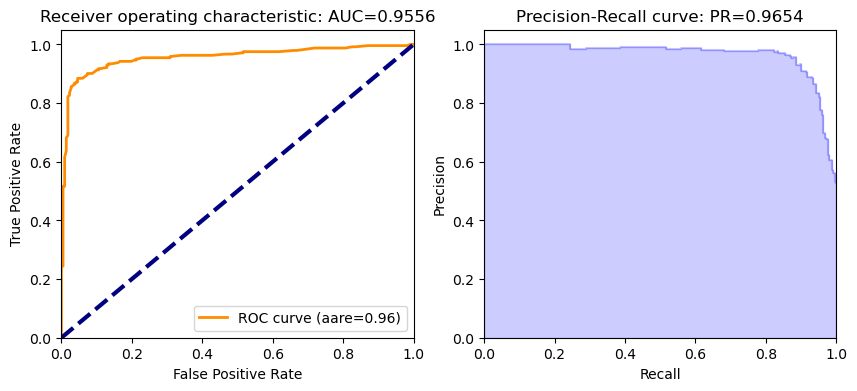

```python
def ROC_AUC(my_result,df,target):
    from sklearn.metrics import roc_curve,auc
    from sklearn.metrics import average_precision_score
    from sklearn.metrics import precision_recall_curve
    import matplotlib.pyplot as plt

    # ROC
    y_actual = df[target].as_data_frame()
    y_pred = my_result.predict(df).as_data_frame()
    fpr = list()
    tpr = list()
    roc_auc = list()
    fpr,tpr,_ = roc_curve(y_actual,y_pred)
    roc_auc = auc(fpr,tpr)

    # Precision-Recall
    average_precision = average_precision_score(y_actual,y_pred)

    print('')
    print('   * ROC curve: The ROC curve plots the true positive rate vs. the false rositive sate')
    print('')
    print('	  * The area under the curve (AUC): A value between 0.5 (random) and 1.0 (perfect), measuring the prediction accuracy')
    print('')
    print('   * Recall (R) = The number of true positives / (the number of true positives + the number of false negatives)')
    print('')

    # plotting
    plt.figure(figsize=(10,4))

    # ROC
    plt.subplot(1,2,1)
    plt.plot(fpr,tpr,color='darkorange',lw=2,label='ROC curve (aare=%0.2f)' % roc_auc)
    plt.plot([0,1],[0,1],color='navy',lw=3,linestyle='--')
    plt.xlim([0.0,1.0])
    plt.ylim([0.0,1.05])
    plt.xlabel('False Positive Rate')
    plt.ylabel('True Positive Rate')
    plt.title('Receiver operating characteristic: AUC={0:0.4f}'.format(roc_auc))
    plt.legend(loc='lower right')

    # Precision-Recall
    plt.subplot(1,2,2)
    precision,recall,_ = precision_recall_curve(y_actual,y_pred)
    plt.step(recall,precision,color='b',alpha=0.2,where='post')
    plt.fill_between(recall,precision,step='post',alpha=0.2,color='b')
    plt.xlabel('Recall')
    plt.ylabel('Precision')
    plt.ylim([0.0,1.05])
    plt.xlim([0.0,1.0])
    plt.title('Precision-Recall curve: PR={0:0.4f}'.format(average_precision))
    plt.show()
ROC_AUC(rf_v1,test_hex,'loan_default')
```

- My thoughts: After oversampling, I implement random forest classifier model with parameter tuning. The ROC significantly increases to 0.96 from 0.63

#### Limitation and further improvemenrt

- Imputation of NA and anomaly can be more creative with functions creaeted.
- Incorporation WOE into model can improve the accracy further.
- Advanced machine learning model with hyper parameter tuning can improve the accuracy, for example, XGBoost, svm, etc
- Deep Learning model with multiple layer parameter tuning can improve the accuracy, for example, cnn, rnn, etc.